# Multi-year temporal deep learning and open satellite data lower the detectability floor for low-severity spruce beetle mortality in Southcentral Alaska

Author

Seamus Murphy

Published

August 12, 2026

Abstract

Spruce beetle (*Dendroctonus rufipennis*) has killed spruce across Southcentral Alaska since about 2016, yet roughly ninety percent of the mortality sits in stands of areal severity below 0.05, beneath the detection floor of conventional Landsat change analysis, and the aerial survey record understates exactly this dispersed, low-severity damage. We test whether temporal deep learning on freely available satellite time series lowers that floor. Annual Sentinel-2 composites, cloud-screened with Cloud Score+ quality mosaics on a 90 m stand grid, feed subsequence models, a temporal convolutional network and a Transformer encoder, augmented with annual climate variables that govern spruce beetle development and survival, a warmth index built on the 17 °C univoltinism threshold, winter minimum temperature and lagged summer means, trained on dead-spruce crowns digitised from statewide sub-metre image mosaics of 2020 and 2023; comparison of the two epochs supplies interval-censored mortality-onset labels, verified pre-mortality trajectories and a cross-epoch consistency check on the labels themselves. Models are benchmarked against the pre- to post-outbreak shortwave-infrared reflectance change that defines the current floor, under block spatial cross-validation, with skill reported per severity stratum and evaluated independently against a published high-resolution severity product whose footprint no training fold touches. [Detection skill in the 0.01 to 0.10 stratum: pending.] [Detectability floor per method: pending.] [Onset-dating error and the effect of interval supervision: pending.] [Contribution of climate variables to detection skill: pending.] [Correspondence of the reconstructed 2016 to 2025 outbreak progression with the aerial survey record: pending.] The severity strata, metrics and decision rules were fixed by pre-registration before outcome data were analysed.

```r
library(sf)
library(terra)
root <- normalizePath("..")
inputs <- file.path(root, "02.inputs")

# House table format: 9 pt, centred headers, numeric right / text left,
# single line spacing.
fmt_tbl <- function(df, right = NULL) {
  right_cols <- union(names(df)[vapply(df, is.numeric, TRUE)], right)
  left_cols <- setdiff(names(df), right_cols)
  ft <- flextable::flextable(df)
  ft <- flextable::fontsize(ft, size = 9, part = "all")
  ft <- flextable::align(ft, align = "center", part = "header")
  if (length(right_cols))
    ft <- flextable::align(ft, j = right_cols, align = "right", part = "body")
  if (length(left_cols))
    ft <- flextable::align(ft, j = left_cols, align = "left", part = "body")
  ft <- flextable::line_spacing(ft, space = 1, part = "all")
  ft <- flextable::padding(ft, padding.top = 1, padding.bottom = 1,
                           part = "all")
  flextable::set_table_properties(ft, layout = "autofit", width = 1)
}
```

# Introduction

The boreal forest of Southcentral Alaska supplies subsistence resources, timber, wildlife habitat and carbon storage, and its dynamics are governed to an unusual degree by a single biotic agent. Recurrent spruce beetle (*Dendroctonus rufipennis*) outbreaks have shaped the spruce forests of the region for centuries, with outbreak extent linked to summer temperatures (Berg, David Henry, Fastie, De Volder, & Matsuoka, 2006). From 1990 to 2000 an extensive outbreak caused spruce mortality across 1.19 million ha of Alaskan forest, roughly 40% more area than had been infested in the previous 70 years (Werner, Holsten, Matsuoka, & Burnside, 2006), and a new outbreak under way in Southcentral Alaska since about 2016 has spread from the Susitna lowlands toward the Alaska Range (Zwieback et al., 2024). Identifying where and when beetle-caused mortality occurs, and at what severity, is foundational to hazard management, to carbon accounting and to understanding how a warming climate reshapes boreal disturbance regimes (Hicke et al., 2024). Yet the operational damage record for Alaska rests on aerial sketch mapping, whose polygons carry coarse positional accuracy, record only what an observer saw from the air that year, and understate dispersed low-severity mortality (Hicke et al., 2024; Zwieback et al., 2024).

The climate dependence of these outbreaks operates through the beetle’s biology, stage by stage. Adults fly in early summer, colonise windthrown, stressed or, at outbreak densities, healthy spruce through pheromone-coordinated mass attack that overwhelms host resin defences, and lay eggs in phloem galleries; larvae develop and overwinter beneath the bark, and populations build in downed and weakened hosts before erupting onto live stands (Werner et al., 2006). Temperature regulates every step. The generation normally takes two years, but warm summers shift brood to a one-year cycle, and the univoltine proportion is predictable from cumulative hours above 17 °C in the weeks following peak flight (Hansen, Bentz, & Turner, 2001); a halved generation time compounds population growth. Milder winters raise overwinter survival of the life stages beneath the bark, and both mechanisms link bark beetle outbreak likelihood to warming across western North America (Bentz et al., 2010). In Southcentral Alaska specifically, tree-ring reconstructions and the survey record tie outbreak extent to running-mean summer temperature over more than two centuries (Berg et al., 2006; Sherriff, Berg, & Miller, 2011).

This biology has a methodological consequence that remote sensing has not exploited. The years in which populations can erupt, and hence the years in which canopy decline can begin, are partially forecastable from air temperature alone; a spectral decline that follows consecutive warm summers and mild winters is more probably beetle-caused than an identical decline that does not, and the converse helps separate beetle mortality from drought stress, whose spectral expression is similar but whose climatic precursors differ. Detection models that see only reflectance discard this information. The models developed here receive the climate variables that the biology nominates, a summer warmth index anchored on the univoltinism threshold, winter minimum temperature, and lagged summer means, as input channels alongside the spectral time series, and the study tests whether that biological information measurably improves detection.

Satellite remote sensing offers the systematic record that survey flights cannot. The Landsat archive provides four decades of calibrated observation at a resolution suited to stand-scale disturbance (Wulder et al., 2019), and its availability in cloud platforms has made time-series analysis routine (Gorelick et al., 2017). The established approach extracts temporal features from spectral index trajectories with segmentation algorithms such as LandTrendr (Kennedy, Yang, & Cohen, 2010) or continuous change methods such as CCDC (Zhu & Woodcock, 2014) and classifies them with ensemble learners. These methods detect abrupt, stand-replacing disturbance reliably, but their outputs diverge widely for subtle change, and their skill degrades exactly where insect damage lives: partial, gradual disturbance whose trajectories merge with natural forest variation (Cohen et al., 2017; Senf, Seidl, & Hostert, 2017). For bark beetles the mature capability is mapping the red and gray stages of heavily killed stands; low-severity and dispersed mortality remain the recognized frontier (Hicke et al., 2024; Senf et al., 2017).

The size of that gap in Alaska is now quantified. Zwieback et al. (2024) mapped dead spruce at tree scale from 2 m WorldView-2 imagery with a convolutional network at 95% average accuracy, and found that roughly 90% of beetle-killed spruce in their Southcentral study area stood in stands of areal severity below 0.05, while stand-scale Landsat SWIR reflectance change related clearly to severity only above 0.1. In this landscape of mixed forest with low conifer fractions, nearly all mortality therefore sits beneath the detection floor of conventional Landsat change analysis. High-resolution mapping closes that gap but at the cost of proprietary imagery, which constrains both operational reuse and retrospective analysis. Statewide alternatives have not resolved it either: Alaska-wide change attribution has relied on intersecting Landsat trends with the same coarse survey perimeters (Pastick et al., 2018), occurrence models predict beetle habitat rather than damage (Zabihi, Huettmann, & Young, 2021), and individual-tree mortality benchmarks, which show that spatial resolution outweighs spectral depth for detecting dead crowns, exist only outside Alaska (Khatri-Chhetri, Wagtendonk, Hendryx, & Kane, 2024).

Deep learning applied to the temporal dimension offers a route below the index-based floor. One-dimensional convolutional networks (Pelletier, Webb, & Petitjean, 2019) and self-attention models (Rußwurm & Körner, 2020) classify satellite image time series without handcrafted temporal features, learning which parts of a trajectory discriminate. Applied to annual Landsat subsequences over the boreal forest of eastern Canada, TempCNN and Transformer models detected and dated partial and progressive disturbances that LandTrendr-based classification missed, producing the first satellite-derived epidemic maps for the eastern spruce budworm (Perbet, Guindon, Côté, & Béland, 2024). Whether that result transfers from a defoliator in Quebec to a bark beetle in Alaska is unknown, and the transfer is not trivial: agent, host, landscape and label regime all differ, and reviews caution against porting detection results across pest-host systems (Kautz, Feurer, & Adler, 2024). The biology, however, favours Alaska. Unlike *Ips typographus*, where trees fade within months and detection races beetle emergence (Kautz et al., 2024), *Dendroctonus*-attacked spruce fade over years, in Alaska from green through red to gray (Hicke et al., 2024), so the spectral signal accumulates over time scales that annual composites resolve. What has been missing is a reference severity dataset commensurable with the satellite grid, and that now exists: the tree-scale severity product of Zwieback et al. (2024), released openly at 30 to 250 m stand scales, together with sub-metre statewide image mosaics on which additional reference labels can be digitised.

This study evaluates deep learning methods and open satellite time series against that reference, and tests whether feeding the models the climate variables that govern beetle development and survival improves what they can see. We assemble annual Sentinel-2 and Landsat composites over Southcentral Alaska, train subsequence models (after Perbet et al., 2024) against stand-scale severity reference data, and benchmark them against the pre- to post-outbreak SWIR reflectance change baseline that defines the current detection floor (Zwieback et al., 2024). Our objectives are to (1) quantify the skill with which open satellite time series estimate stand-scale areal severity of beetle-associated mortality, reported per severity stratum; (2) determine the detectability floor, the lowest severity stratum at which detection skill exceeds a pre-registered threshold, for each method; (3) estimate the year of mortality onset, supervised by onset intervals triangulated between the two label epochs, and quantify its lag relative to the reference record; (4) quantify the contribution of biologically motivated climate variables to detection skill; and (5) reconstruct the annual progression of the outbreak from its 2016 onset through the present across the Matanuska-Susitna Borough application extent, evaluating the reconstruction against the aerial survey archive.

We test three hypotheses, all over the complete outbreak trajectory from 2016 through the present rather than the single dates or two-epoch differences of prior work. Under the null (H0), temporal deep learning models do not exceed the skill of the SWIR change baseline below areal severity of 0.1, and the detection floor of Zwieback et al. (2024) stands. Under the alternative (H1), subsequence models achieve significantly higher detection skill than the baseline within the 0.01 to 0.10 severity stratum, lowering the floor at which freely available imagery can monitor spruce beetle mortality. The second hypothesis concerns temporal supervision, which single-date mapping cannot provide: under H2, models trained with mortality-onset intervals triangulated between the 2020 and 2023 label epochs date onset more accurately than the same models trained on single-epoch labels. The third hypothesis carries the climate mechanism into the detection problem: under H3, models receiving annual climate channels, a summer warmth index anchored on the 17 °C univoltinism threshold (Hansen et al., 2001), winter minimum temperature, and lagged summer means (Berg et al., 2006), detect low-severity mortality better than spectrally identical models without them. Secondarily, we expect estimated onset years to lag true onset by one to two years, as observed for gradual disturbances elsewhere in the boreal (Perbet et al., 2024). The severity strata, skill metrics and decision thresholds are fixed by pre-registration before any outcome data are analysed.

# Materials and methods

All inputs are open source; scripted retrieval, integrity checksums and a provenance manifest accompany the analysis code.

## Study area

The study area is the Southcentral Alaska outbreak region, centred on the Susitna lowlands and Matanuska-Susitna Valley and bounded by the Talkeetna Mountains and the Alaska Range, in the NAD83 Alaska Albers projection. Forests are boreal mosaics of white spruce (*Picea glauca*), black spruce (*P. mariana*), paper birch (*Betula neoalaskana*) and trembling aspen (*Populus tremuloides*), with wetlands and mixed stands in which conifer fractions of 10 to 30% predominate (Zwieback et al., 2024). The ongoing outbreak reached the area around 2016 and had exhausted much of the large white spruce by 2021 (Zwieback et al., 2024). The temporal window of the study spans the full history of this outbreak, from its onset around 2016 through the most recent survey year, observed by annual Sentinel-2 and Landsat composites; earlier Landsat years enter only as the undisturbed pre-outbreak baseline against which the outbreak trajectory is measured. Model training and cross-validation blocks span the confirmatory study window, a 39,050 km2 frame around the reference footprint; the Talkeetna to Byers Lake footprint of the independent severity reference serves as the held-out evaluation area for the severity product. A larger application extent, the Matanuska-Susitna Borough, receives the trained model’s wall-to-wall severity and progression maps for management use; predictions outside the confirmatory window are application products whose transfer is not confirmed by the cross-validation, and are labelled accordingly. Severity summaries are additionally reported per stand of the state Mat-Su Borough forest inventory for use by forest managers.

All spatial figures share one cartographic standard: the working grid is WGS 84 UTM zone 5N, matching the severity reference grid, graticules are drawn in the same projected grid, and every map declares its coordinate reference system and representative fraction. Figure 1 locates the study area and the recorded outbreak footprint.

```r
library(ggplot2); library(ggspatial)
tpl_map <- rast(file.path(inputs, "zwieback-severity", "merged_ref_h_c90c.tif"))
foot <- st_as_sf(as.polygons(ext(tpl_map), crs = crs(tpl_map)))
ctx <- file.path(inputs, "context", "naturalearth.gpkg")
matsu38 <- st_transform(st_read(ctx, "matsu_borough", quiet = TRUE), 3338)
bb3338 <- ext(vect(matsu38)) + 20000
tmp <- tempfile(fileext = ".gpkg")
gdal_utils("vectortranslate",
           file.path(inputs, "ids-region10", "AK_Region10_AllYears.gdb"), tmp,
           options = c("-where",
                       "SURVEY_YEAR >= 2016 AND DCA_CODE IN (11009,80007)",
                       "-spat", bb3338[1], bb3338[3], bb3338[2], bb3338[4],
                       "DAMAGE_AREAS_FLAT_AllYears_AK_Rgn10"))
ids_map <- st_transform(st_read(tmp, quiet = TRUE), st_crs(foot))
matsu <- st_transform(st_read(ctx, "matsu_borough", quiet = TRUE), 32605)
win_rect <- st_as_sfc(st_bbox(st_buffer(foot, 50000)))
if (!file.exists(ctx)) {
  dir.create(dirname(ctx), showWarnings = FALSE)
  grab <- function(type, cat) {
    x <- rnaturalearth::ne_download(10, type, cat, returnclass = "sf")
    x$name <- x[[intersect(c("name", "NAME"), names(x))[1]]]
    x["name"]
  }
  st_write(grab("rivers_lake_centerlines", "physical"), ctx, "rivers",
           quiet = TRUE, delete_dsn = TRUE)
  st_write(grab("roads", "cultural"), ctx, "roads", quiet = TRUE,
           append = TRUE)
  st_write(grab("populated_places", "cultural"), ctx, "places",
           quiet = TRUE, append = TRUE)
}
if (!"places_census" %in% st_layers(ctx)$name) {
  pl <- tigris::places(state = "AK", year = 2023, progress_bar = FALSE)
  pl$name <- pl$NAME
  st_write(st_centroid(pl["name"]), ctx, "places_census", quiet = TRUE,
           append = TRUE)
}
ev <- st_bbox(st_buffer(matsu, 15000))
clipctx <- function(layer) {
  x <- st_read(ctx, layer, quiet = TRUE)
  x <- x[st_transform(st_as_sfc(ev), st_crs(x)), ]
  suppressWarnings(st_crop(st_transform(x, 32605), ev))
}
riv <- clipctx("rivers"); rds <- clipctx("roads")
plc <- clipctx("places_census")
plc <- plc[plc$name %in% c("Cantwell", "Talkeetna", "Trapper Creek",
                           "Petersville", "Skwentna", "Willow", "Houston",
                           "Big Lake", "Sutton-Alpine", "Wasilla", "Palmer"), ]
plc <- st_sf(st_drop_geometry(plc), geometry = st_geometry(plc))
gw <- ev["xmax"] - ev["xmin"]; gh <- ev["ymax"] - ev["ymin"]
sub_utm <- sprintf("1:%s  ·  UTM zone 5N (EPSG:32605)",
                   format(round(as.numeric(gw) / 0.170, -5), big.mark = " "))

map_theme <- theme_bw(base_size = 8) +
  theme(panel.grid = element_line(colour = "grey70", linewidth = .25,
                                  linetype = "dotted"),
        axis.title = element_blank(),
        axis.text = element_text(size = 6, colour = "grey25"),
        plot.title = element_text(face = "bold", size = 8.5,
                                  margin = margin(b = 1)),
        plot.subtitle = element_text(size = 6, colour = "grey35",
                                     margin = margin(b = 3)),
        legend.position = "bottom",
        legend.title = element_text(size = 6.5),
        legend.text = element_text(size = 6))
north <- annotation_north_arrow(location = "tr", which_north = "true",
  height = unit(6, "mm"), width = unit(5, "mm"),
  pad_x = unit(1.2, "mm"), pad_y = unit(1.2, "mm"),
  style = north_arrow_orienteering(text_size = 5, line_width = .6,
    fill = c("white", "grey20"), text_col = "grey20"))
plate <- annotate("rect", xmin = ev["xmin"] + .885 * gw, xmax = ev["xmax"],
                  ymin = ev["ymax"] - .115 * gh, ymax = ev["ymax"],
                  fill = "white", alpha = .72, colour = NA)

fig_study <- ggplot() +
  geom_sf(data = ids_map, aes(fill = "Aerial survey spruce beetle damage"),
          colour = NA) +
  geom_sf(data = riv, aes(colour = "River"), linewidth = .4) +
  geom_sf(data = rds, aes(colour = "Highway"), linewidth = .45) +
  geom_sf(data = matsu, aes(colour = "Application extent, Mat-Su Borough"),
          fill = NA, linewidth = .5) +
  geom_sf(data = win_rect, aes(colour = "Confirmatory study window"),
          fill = NA, linewidth = .5, linetype = "22") +
  geom_sf(data = foot, aes(colour = "Severity reference footprint"),
          fill = NA, linewidth = .6) +
  geom_sf(data = plc, aes(shape = "Settlement"), colour = "grey15",
          size = .9) +
  ggrepel::geom_text_repel(
    data = plc, aes(label = name, geometry = geometry),
    stat = "sf_coordinates", size = 2.3, colour = "grey15",
    fontface = "italic", seed = 7, box.padding = .25,
    bg.color = "white", bg.r = .12) +
  scale_fill_manual(NULL, values = c("Aerial survey spruce beetle damage" =
                                       "grey82")) +
  scale_colour_manual(NULL, values = c(
    "Application extent, Mat-Su Borough" = "grey10",
    "Confirmatory study window" = "#E67E22",
    "Severity reference footprint" = "#C0392B",
    "River" = "steelblue3", "Highway" = "grey35")) +
  scale_shape_manual(NULL, values = c("Settlement" = 16)) +
  guides(colour = guide_legend(order = 2, nrow = 3),
         fill = guide_legend(order = 1, nrow = 3),
         shape = guide_legend(order = 3, nrow = 3)) +
  coord_sf(crs = 32605, datum = st_crs(32605), expand = FALSE,
           xlim = ev[c("xmin", "xmax")], ylim = ev[c("ymin", "ymax")]) +
  plate + north + map_theme +
  labs(title = "Analysis extents", subtitle = sub_utm)
fig_study
dir.create(file.path(root, "03.outputs", "figures"), showWarnings = FALSE)
ggsave(file.path(root, "03.outputs", "figures", "fig-studyarea.png"),
       fig_study, width = 170, height = 195, units = "mm", dpi = 500,
       bg = "white")
```

[figure not shown]

Figure 1: Analysis extents in Southcentral Alaska. The black outline is the application extent, the Matanuska-Susitna Borough (United States Census Bureau boundary); the dashed orange rectangle is the confirmatory study window holding all training blocks and cross-validation folds; the red rectangle is the footprint of the independent severity reference. Grey polygons are aerial detection survey records of spruce beetle damage, 2016 to 2025. Blue lines are rivers, dark grey lines are highways, and labelled points are settlements (United States Census Bureau TIGER places; rivers and highways from Natural Earth 10 m). Representative fraction and coordinate reference system as titled; graticule in UTM zone 5N eastings and northings.

## Input datasets

The study draws on nine input datasets in four roles (Table 1). Reference data are what the models learn from and are judged against: our own crown delineations digitised on the two State of Alaska Maxar mosaic epochs, seeded by the released labels and network of Zwieback et al. (2024), and the independent severity rasters of the same study. Predictor data are what the models see: annual Sentinel-2 and Landsat composites. Covariates condition sampling and interpretation: terrain and conifer fraction (Macander et al., 2022). Weak spatial context stratifies the sample and separates surveyed absence from non-survey: the aerial detection survey polygons and their flown-area footprints. The downloadable reference and context datasets are checksum-verified at retrieval; predictor assembly precedes no outcome analysis, which waits behind pre-registration.

```r
inp <- data.frame(
  Dataset = c(
    "Severity rasters (Zwieback)", "Crown labels (Zwieback)",
    "Trained CNN (Zwieback)", "Maxar mosaics (AK Geoportal)",
    "IDS damage polygons", "Sentinel-2 L2A", "Landsat Collection 2",
    "IFSAR DEM", "Conifer fraction (Macander)"),
  Role = c(
    "Independent severity reference", "Seed labels for digitisation",
    "Pre-labelling model", "Label imagery (crown digitisation)",
    "Sample stratification; surveyed-absence masks",
    "Predictor time series", "Predictor time series; pre-outbreak baseline",
    "Static covariate", "Static covariate"),
  Resolution = c("30 / 90 / 250 m", "vector", "n.a.", "0.5 m (2020); 0.3 m (2023)",
                 "polygon", "10-20 m", "30 m", "5 m", "30 m"),
  Epoch = c("2021", "c. 2021", "n.a.", "2020; 2023", "1997-2025",
            "2016-present", "1984-present", "static", "2020"),
  Source = c(
    "Zenodo 10.5281/zenodo.8423568", "Zenodo 10.5281/zenodo.10569990",
    "Zenodo 10.5281/zenodo.10569975", "gis.data.alaska.gov (streaming)",
    "USFS FHP, Region 10 geodatabase", "Copernicus / GEE", "USGS / GEE",
    "elevation.alaska.gov", "ORNL DAAC / GEE"),
  Licence = c(
    "None declared; clarification pending", "CC-BY 4.0", "CC-BY 4.0",
    "Non-commercial streaming, no redistribution", "Public domain",
    "Open (Copernicus)", "Public domain", "Public domain", "Open"))
names(inp) <- c("Dataset", "Role", "Resolution", "Epoch", "Source", "Licence")
fmt_tbl(inp)
```

Table 1: Input datasets, their roles, and access terms.

| Dataset | Role | Resolution | Epoch | Source | Licence |
| --- | --- | --- | --- | --- | --- |
| Severity rasters (Zwieback) | Independent severity reference | 30 / 90 / 250 m | 2021 | Zenodo 10.5281/zenodo.8423568 | None declared; clarification pending |
| Crown labels (Zwieback) | Seed labels for digitisation | vector | c. 2021 | Zenodo 10.5281/zenodo.10569990 | CC-BY 4.0 |
| Trained CNN (Zwieback) | Pre-labelling model | n.a. | n.a. | Zenodo 10.5281/zenodo.10569975 | CC-BY 4.0 |
| Maxar mosaics (AK Geoportal) | Label imagery (crown digitisation) | 0.5 m (2020); 0.3 m (2023) | 2020; 2023 | gis.data.alaska.gov (streaming) | Non-commercial streaming, no redistribution |
| IDS damage polygons | Sample stratification; surveyed-absence masks | polygon | 1997-2025 | USFS FHP, Region 10 geodatabase | Public domain |
| Sentinel-2 L2A | Predictor time series | 10-20 m | 2016-present | Copernicus / GEE | Open (Copernicus) |
| Landsat Collection 2 | Predictor time series; pre-outbreak baseline | 30 m | 1984-present | USGS / GEE | Public domain |
| IFSAR DEM | Static covariate | 5 m | static | elevation.alaska.gov | Public domain |
| Conifer fraction (Macander) | Static covariate | 30 m | 2020 | ORNL DAAC / GEE | Open |

## Training data

Stand-scale areal severity of beetle-associated dead spruce for the Talkeetna to Byers Lake area in 2021, derived by Zwieback et al. (2024) from a convolutional network applied to WorldView-2 imagery, is used at three released stand scales solely for independent evaluation. Metadata are inspected here; values are neither summarised nor plotted before pre-registration.

```r
sev <- lapply(c("merged_ref_h_c30c.tif", "merged_ref_h_c90c.tif",
                "merged_ref_h_c250c.tif"),
              function(f) rast(file.path(inputs, "zwieback-severity", f)))
data.frame(
  file       = vapply(sev, function(r) basename(sources(r)), ""),
  resolution = vapply(sev, function(r) paste(round(res(r)), collapse = " x "), ""),
  ncell      = vapply(sev, ncell, numeric(1)),
  crs        = vapply(sev, function(r) st_crs(crs(r))$Name, "")
)
```

| file | resolution | ncell | crs |
| --- | --- | --- | --- |
| merged_ref_h_c30c.tif | 30 x 30 | 10442793 | WGS 84 / UTM zone 5N |
| merged_ref_h_c90c.tif | 90 x 90 | 1159703 | WGS 84 / UTM zone 5N |
| merged_ref_h_c250c.tif | 250 x 250 | 151011 | WGS 84 / UTM zone 5N |

## Crown labels

Reference labels are produced by machine-assisted digitisation of dead spruce crowns on the statewide sub-metre mosaics, acquired in 2020 at 0.5 m and in 2023 at 0.3 m resolution, over sample blocks stratified by conifer fraction and survey-recorded damage history. Imagery is obtained as four-band chips from the USDA NRCS image services, whose export endpoint carries the same mosaics. The route is public but the pixels are not: the service records the Alaska Vivid imagery as a dataset licensed from Maxar to USDA-FPAC in 2020, with copyright retained by the vendor. Imagery is therefore processed locally and never redistributed, and what this study publishes from it are the derived crown delineations and stand-level severity fractions, not the pixels, on the same footing as the published delineations of Zwieback et al. (2024), which were drawn on proprietary imagery that their release could not include. Label preparation runs in four stages.

1. **Pre-labelling.** The released dead-spruce network of Zwieback et al. (2024) is the only domain-tuned component available, but it cannot be applied to these mosaics as released. It was trained on seven pansharpened WorldView-2 bands, blue, green, yellow, red, red edge and two near-infrared bands, and its encoder’s first layer was widened from three channels to seven to match; the four-band mosaics used here supply no yellow, red-edge or second near-infrared channel. The network is therefore adapted rather than applied: the first-layer weights for the four channels the two sensors share are retained, the remaining three discarded, and the network fine-tuned on the published crown labels of the same study, which are rasterised against mosaic imagery over their own delineation areas. Those areas, not the sample blocks, supply the tuning imagery, because the delineations intersect only four blocks and all four fall in the held-out reference fold.
2. **Crown segmentation.** Candidate detections are refined into crown polygons with general-purpose segmentation models: DeepForest crown detection (Weinstein, Marconi, Bohlman, Zare, & White, 2019) supplying box prompts to the Segment Anything Model (SAM2) through the segment-geospatial toolchain (Wu & Osco, 2023), an established zero-shot pipeline for tree delineation. Segmentation runs on the project’s cloud GPU; outputs are vector crown candidates scored by the dead-spruce probability.
3. **Cleaning and triage.** Candidates below a minimum crown area or outside plausible crown geometry are dropped; overlapping detections are merged. Two annotators then accept, edit or reject each candidate independently in QGIS, with a third adjudicating disagreements (after Khatri-Chhetri et al., 2024). Fully occluded dead spruce under closed deciduous canopy remain undetectable in RGB imagery and are an acknowledged limitation carried forward from Zwieback et al. (2024).
4. **Aggregation, triangulation and classification.** Accepted crowns are rasterised to stand-cell areal severity fractions at 30 and 90 m, and each labelled stand is classified as low, medium or high disturbance at the pre-registered severity breaks. Cross-epoch triangulation then assigns every crown a temporal state: dead by 2020, died between 2020 and 2023, or alive through 2023, yielding interval-censored onset labels for the dating head, verified pre-mortality trajectories for exploratory green-stage analysis, and confirmed-alive negatives. The same comparison cleans the labels: a crown dead in 2020 must remain dead in 2023, and violations are returned to triage, a consistency check unavailable to single-epoch designs.

The published crown labels of Zwieback et al. (2024), distributed under an attribution licence, additionally enter the training pool within their delineation areas, contributing temporal cuts at their image dates of 2018 and 2021. Combined with the 2020 and 2023 mosaic epochs, four temporal cuts are available in the Talkeetna to Byers Lake area, narrowing onset brackets there to one to two years. The severity rasters of Zwieback et al. (2024), by contrast, take no part in label preparation; they remain the untouched independent evaluation dataset described under Model evaluation.

Tuning pairs are assembled below: for each delineation area holding crowns, a four-band chip at the 2020 mosaic resolution and the matching crown mask rasterised from the published polygons. The crowns were delineated on imagery of August 2021, one year after the 2020 mosaic, so a crown that died during that year is marked dead over imagery in which it was still living. This is label noise of known sign, and it is one-directional: it can only teach the network that living crowns are dead, never the reverse. Its size is bounded by the fraction of crowns dying in that single year and is reported with the pairs.

```r
lab_dir <- file.path(inputs, "zwieback-labels", "gpkg")
pair_dir <- file.path(inputs, "label-pairs")
dir.create(pair_dir, showWarnings = FALSE)
lab_f <- list.files(lab_dir, pattern = "_labels[.]gpkg$", full.names = TRUE)
pairs_csv <- file.path(dirname(inputs), "03.outputs", "label_pairs.csv")

if (!file.exists(pairs_csv)) {
  library(sf)
  GSD <- 0.5                       # 2020 mosaic ground sample distance, metres
  rows <- list()
  options(timeout = 300)
  for (f in lab_f) {
    l <- suppressWarnings(st_read(f, quiet = TRUE))
    if (nrow(l) == 0) next
    id <- sub("_labels[.]gpkg$", "", basename(f))
    # One delivered file (area 0033, 73 crowns) declares EPSG:4326 while its
    # coordinates are UTM zone 5N metres, which makes st_area report a crown as
    # billions of square metres. Relabel without transforming; the coordinates
    # were always UTM.
    if (!identical(st_crs(l)$epsg, 32605L)) {
      bb0 <- suppressWarnings(st_bbox(l))
      if (bb0[["xmin"]] > 1000) l <- st_set_crs(l, 32605)
    }
    bb <- st_bbox(l)
    px <- round(c(bb["xmax"] - bb["xmin"], bb["ymax"] - bb["ymin"]) / GSD)
    img_f <- file.path(pair_dir, sprintf("%s_img.tif", id))
    msk_f <- file.path(pair_dir, sprintf("%s_mask.tif", id))
    if (!file.exists(img_f)) {
      u <- sprintf(paste0(
        "https://apps.geo.fpac.usda.gov/nrcs-imagery/rest/services/",
        "ortho_imagery/alaska_vivid_2020_50cm/ImageServer/exportImage?",
        "bbox=%f,%f,%f,%f&bboxSR=32605&imageSR=32605&size=%d,%d",
        "&format=tiff&f=image"),
        bb["xmin"], bb["ymin"], bb["xmax"], bb["ymax"], px[1], px[2])
      ok <- FALSE
      for (attempt in 1:3) {          # the public service drops requests
        ok <- !inherits(try(download.file(u, img_f, mode = "wb", quiet = TRUE),
                            silent = TRUE), "try-error")
        if (ok && inherits(try(rast(img_f), silent = TRUE), "try-error")) {
          unlink(img_f); ok <- FALSE  # HTML error body, not imagery
        }
        if (ok) break
        Sys.sleep(2)
      }
      # A silent `next` here would drop the area from the table and make a
      # failed fetch look like an area that never had crowns.
      if (!ok) {
        rows[[id]] <- data.frame(area = id, crowns = nrow(l),
          chip_px = "FETCH FAILED", bands = NA_integer_,
          crown_area_m2 = round(sum(as.numeric(st_area(l)))),
          pct_crown = NA_real_)
        next
      }
      Sys.sleep(0.5)
    }
    img <- rast(img_f)
    if (!file.exists(msk_f)) {
      m <- rasterize(vect(l), rast(img[[1]]), field = 1, background = 0)
      writeRaster(m, msk_f, overwrite = TRUE, datatype = "INT1U")
    }
    m <- rast(msk_f)
    rows[[id]] <- data.frame(
      area = id, crowns = nrow(l),
      chip_px = sprintf("%d x %d", ncol(img), nrow(img)),
      bands = nlyr(img),
      crown_area_m2 = round(sum(as.numeric(st_area(l)))),
      pct_crown = round(100 * global(m, "mean", na.rm = TRUE)[1, 1], 2))
  }
  write.csv(do.call(rbind, rows), pairs_csv, row.names = FALSE)
}
pairs <- read.csv(pairs_csv)
```

```r
fmt_tbl(rbind(head(pairs[order(-pairs$crowns), ], 8),
              data.frame(area = sprintf("all %d areas", nrow(pairs)),
                         crowns = sum(pairs$crowns), chip_px = "",
                         bands = NA,
                         crown_area_m2 = sum(pairs$crown_area_m2),
                         pct_crown = round(mean(pairs$pct_crown), 2))),
        right = c("crowns", "bands", "crown_area_m2", "pct_crown"))
```

Table 2: Tuning pairs assembled from the published crown delineations: four-band mosaic imagery at 0.5 m with the crown mask rasterised to the same grid, one pair per delineation area holding crowns. Percent crown is the share of chip pixels falling inside a delineated dead crown, which is the class balance the fine-tuning must contend with.

| area | crowns | chip_px | bands | crown_area_m2 | pct_crown |
| --- | --- | --- | --- | --- | --- |
| 88 | 1,393 | 1027 x 1025 | 4 | 23,362 | 8.89 |
| 1004 | 897 | 1024 x 1025 | 4 | 18,621 | 7.10 |
| 90 | 738 | 1029 x 768 | 4 | 24,625 | 12.32 |
| 1011 | 709 | 1029 x 1025 | 4 | 14,872 | 5.65 |
| 89 | 471 | 582 x 1002 | 4 | 11,162 | 7.64 |
| 69 | 448 | 1026 x 1025 | 4 | 6,425 | 2.44 |
| 91 | 422 | 1024 x 1025 | 4 | 4,618 | 1.76 |
| 74 | 334 | 1027 x 1025 | 4 | 5,662 | 2.15 |
| all 37 areas | 9,194 |  |  | 172,472 | 4.52 |

Of 37 delineation areas holding crowns, 37 yielded imagery, carrying 9,194 of the 9,194 published crowns over 172,472 m² of delineated dead canopy; dead crowns occupy 4.5% of chip pixels on average. That imbalance is the reason the parent study weighted the dead class twenty times the background class, and the same weighting carries over here. Two properties of the delivered labels are worth recording, since neither is documented with them: one area declares a geographic coordinate reference system while holding projected coordinates, which inflates its computed crown areas by nine orders of magnitude if taken at face value, and the delineation areas vary in size by more than two orders of magnitude, so the smallest carry too few pixels to serve as training chips and are dropped at the tiling stage rather than here.

## Crown network

The released network is adapted to the four bands these mosaics carry and fine-tuned on the tuning pairs above. Its first convolution was widened by Zwieback et al. (2024) from three channels to seven to match pansharpened WorldView-2, in the band order blue, green, yellow, red, red edge, near infrared-1 and near infrared-2. The mosaics here are blue, green, red and near infrared, an ordering confirmed from the imagery rather than assumed: the fourth band reaches a 95th percentile far above the visible bands with a floor near zero over water and shadow, which is near-infrared behaviour, and among the visible bands the third is least correlated with it, which is red under chlorophyll absorption. The four matching input filters are therefore copied from the released weights and the three with no counterpart discarded, so tuning starts from learned dead-spruce features rather than from noise. Dead crowns occupy a small minority of pixels, so the loss weights that class twenty to one following the parent study. Areas are split by area, never by tile, so no crop of a validation area is ever seen in training.

The chunk below runs as its own process rather than through reticulate. The manuscript has already loaded sits, which loads the R binding to libtorch, and initialising Python’s torch in the same process loads a second copy of that library and segfaults the session. Running the interpreter as a subprocess keeps the two apart, and the interpreter is named explicitly because the environment’s default resolves to a build that carries no torch.

```python
import os, glob, csv, numpy as np, rasterio, torch, torch.nn as nn

root = os.path.abspath(os.path.join("..", ""))
pair_dir = os.path.join(root, "02.inputs", "label-pairs")
ckpt = os.path.join(root, "02.inputs", "crown_net_4band.pt")
metrics_csv = os.path.join(root, "03.outputs", "crown_net_metrics.csv")

TILE, STRIDE, EPOCHS, DEAD_W = 512, 384, 4, 20.0
# Our band order (blue, green, red, NIR) mapped onto the released model's
# seven WorldView-2 channels (blue, green, yellow, red, red edge, NIR1, NIR2).
KEEP = [0, 1, 3, 5]

# Tiles are indexed, not materialised. Holding all crops in memory costs about
# 580 MB on top of an R session that already holds the composites, which on this
# 8 GB machine drives the process into swap and stalls it; a windowed read per
# crop keeps the footprint to the batch in hand.
def index_of(area):
    with rasterio.open(os.path.join(pair_dir, area + "_img.tif")) as s:
        h, w = s.height, s.width
    if h < TILE or w < TILE:
        return []                     # too small to crop; dropped, counted below
    return [(area, y, x)
            for y in range(0, h - TILE + 1, STRIDE)
            for x in range(0, w - TILE + 1, STRIDE)]

def load(item):
    area, y, x = item
    win = rasterio.windows.Window(x, y, TILE, TILE)
    with rasterio.open(os.path.join(pair_dir, area + "_img.tif")) as s:
        img = s.read(window=win).astype(np.float32) / 255.0
    with rasterio.open(os.path.join(pair_dir, area + "_mask.tif")) as s:
        msk = s.read(1, window=win).astype(np.int64)
    return img, msk

if not (os.path.exists(ckpt) and os.path.exists(metrics_csv)):
    torch.manual_seed(20260812)
    areas = sorted(os.path.basename(f)[:-8]
                   for f in glob.glob(os.path.join(pair_dir, "*_img.tif")))
    val_areas = set(areas[::5])                    # every fifth area held out
    trn_areas = [a for a in areas if a not in val_areas]

    net = torch.load(os.path.join(root, "02.inputs", "zwieback-cnn", "model.p"),
                     map_location="cpu", weights_only=False)
    old = net.backbone.conv1
    new = nn.Conv2d(4, old.out_channels, old.kernel_size, old.stride,
                    old.padding, bias=False)
    with torch.no_grad():
        new.weight.copy_(old.weight[:, KEEP, :, :])
    net.backbone.conv1 = new
    net.aux_classifier = None                      # COCO head, unused here
    dev = torch.device("mps" if torch.backends.mps.is_available() else "cpu")
    net = net.to(dev).train()

    trn = [t for a in trn_areas for t in index_of(a)]
    val = [t for a in sorted(val_areas) for t in index_of(a)]
    loss_fn = nn.CrossEntropyLoss(
        weight=torch.tensor([1.0, DEAD_W], device=dev))
    opt = torch.optim.Adam(net.parameters(), lr=1e-4)

    rows, best_iou = [], -1.0
    for ep in range(EPOCHS):
        net.train()
        order = torch.randperm(len(trn)).tolist()
        tot = 0.0
        for i in range(0, len(order), 2):
            b = [load(trn[j]) for j in order[i:i+2]]
            x = torch.tensor(np.stack([t[0] for t in b])).to(dev)
            y = torch.tensor(np.stack([t[1] for t in b])).to(dev)
            opt.zero_grad()
            l = loss_fn(net(x)["out"], y)
            l.backward(); opt.step()
            tot += float(l.detach()) * len(b)
        net.eval()
        tp = fp = fn = 0
        with torch.no_grad():
            for item in val:
                img, msk = load(item)
                x = torch.tensor(img[None]).to(dev)
                p = net(x)["out"].argmax(1)[0].cpu().numpy()
                tp += int(((p == 1) & (msk == 1)).sum())
                fp += int(((p == 1) & (msk == 0)).sum())
                fn += int(((p == 0) & (msk == 1)).sum())
        prec = tp / (tp + fp) if tp + fp else 0.0
        rec = tp / (tp + fn) if tp + fn else 0.0
        iou = tp / (tp + fp + fn) if tp + fp + fn else 0.0
        # Select on IoU rather than on either half of it: recall alone is
        # maximised by flagging everything, precision alone by flagging nothing,
        # and the checkpoint has to be usable as a pre-labeller. Saving the last
        # epoch instead would keep weights that validate worse than an earlier
        # one, which is what the first run of this chunk did.
        saved = iou > best_iou
        if saved:
            best_iou = iou
            torch.save(net.state_dict(), ckpt)
        rows.append(dict(epoch=ep + 1, train_loss=round(tot / len(trn), 4),
                         val_precision=round(prec, 3), val_recall=round(rec, 3),
                         val_iou=round(iou, 3), checkpointed=saved,
                         n_train_tiles=len(trn), n_val_tiles=len(val),
                         n_train_areas=len(trn_areas), n_val_areas=len(val_areas)))
        # Written every epoch, not once at the end, so progress is visible
        # while the loop runs and a later failure cannot discard earlier epochs.
        with open(metrics_csv, "w", newline="") as f:
            w = csv.DictWriter(f, fieldnames=list(rows[0]))
            w.writeheader(); w.writerows(rows)
```

```r
crown_m <- read.csv(file.path(dirname(inputs), "03.outputs",
                              "crown_net_metrics.csv"))
fmt_tbl(crown_m[, c("epoch", "train_loss", "val_precision", "val_recall",
                    "val_iou", "checkpointed")],
        right = c("epoch", "train_loss", "val_precision", "val_recall",
                  "val_iou"))
```

Table 3: Fine-tuning of the four-band crown network, evaluated per epoch on held-out delineation areas. Precision, recall and intersection over union are pixel-wise against the published delineations, which are themselves imperfect targets over 2020 imagery: a crown that died between the mosaic and the 2021 delineation is marked dead over imagery in which it was still living, so measured precision is a lower bound.

| epoch | train_loss | val_precision | val_recall | val_iou | checkpointed |
| --- | --- | --- | --- | --- | --- |
| 1 | 0.9261 | 0.000 | 0.000 | 0.000 | True |
| 2 | 0.5384 | 0.177 | 0.548 | 0.154 | True |
| 3 | 0.4902 | 0.147 | 0.569 | 0.133 | False |
| 4 | 0.4473 | 0.141 | 0.569 | 0.127 | False |

```r
best <- crown_m[which.max(crown_m$val_iou), ]
```

Tuning used 72 crops from 29 areas against 20 crops from 8 held-out areas. The retained network is the one that validates best rather than the one trained longest: epoch 2, at a recall of 0.55 and a precision of 0.18. Training loss keeps falling after that point while validation intersection over union does not, so the schedule is already past its useful length and the remaining epochs buy recall at a precision the triage queue would pay for. For a pre-labeller feeding human triage the operating direction is nonetheless deliberate: an annotator rejects a false candidate in one action, whereas a crown the network never proposes is never reviewed, and the twenty-to-one class weighting is what buys that recall. These are pixel-wise figures, so the precision an annotator experiences depends on candidate polygons after cleaning rather than on this number directly.

## Spectral separability

Before any label enters training, the spectral basis of the visual classes is tested on the mosaic imagery itself. From the accepted delineations, samples of dead spruce crowns, live conifer crowns and non-forest background are drawn per epoch, and class separability in the available mosaic bands is quantified by pairwise Jeffries-Matusita distance and transformed divergence, with values above 1.9 on the Jeffries-Matusita scale of 0 to 2 taken as strong separability. A principal component analysis of the same samples summarises the band space: component loadings identify which bands carry the dead-crown contrast, and class scores on the first two components are inspected for overlap. Classes that fail separability in an epoch are flagged, and their labels weighted or excluded at the pre-registered decision rule. The assessment runs when label digitisation begins; the code below is inert until then.

```r
# Activated with label digitisation. chips: data.frame of band values with
# class in {dead, live, background} and epoch in {2020, 2023}.
jm <- function(a, b) {
  ma <- colMeans(a); mb <- colMeans(b)
  Sa <- cov(a); Sb <- cov(b); S <- (Sa + Sb) / 2
  B <- t(ma - mb) %*% solve(S) %*% (ma - mb) / 8 +
    log(det(S) / sqrt(det(Sa) * det(Sb))) / 2
  2 * (1 - exp(-B))
}
sep <- lapply(split(chips, chips$epoch), function(e) {
  cl <- split(e[bands_rgb], e$class)
  outer(names(cl), names(cl), Vectorize(function(i, j) jm(cl[[i]], cl[[j]])))
})
pca <- prcomp(chips[bands_rgb], scale. = TRUE)
```

```r
lab_dir <- file.path(inputs, "zwieback-labels", "gpkg")
labs <- list.files(lab_dir, pattern = "_labels\\.gpkg$")
exts <- list.files(lab_dir, pattern = "_extent\\.gpkg$")
c(label_areas = length(labs), extent_files = length(exts))
```

```
 label_areas extent_files
         111          111
```

## Survey polygons

Sketch-mapped damage polygons for Alaska, all survey years, US public domain. These are not labels: positional accuracy is coarse, low-severity damage is under-recorded, and the intensity attribute counts faded trees per treed area, which is not commensurable with pixel-fraction severity (Zwieback et al., 2024). They serve two supporting roles: stratifying the label-block sample by recorded damage history, and, through the flown-area footprints, distinguishing surveyed absence from non-survey. Annual spruce beetle extent is tabulated here as published descriptive context, not as an outcome.

```r
gdb <- file.path(inputs, "ids-region10", "AK_Region10_AllYears.gdb")
st_layers(gdb)
```

| name | geomtype | driver | features | fields | crs |
| --- | --- | --- | --- | --- | --- |
| DAMAGE_AREAS_FLAT_AllYears_AK_Rgn10 | Multi Polygon | OpenFileGDB | 151309 | 42 | NAD83 / Alaska Albers , PROJCRS[“NAD83 / Alaska Albers”, |

[output not shown]

[output not shown]

```r
# The OGR SQL dialect has no GROUP BY; aggregate through GDAL's SQLite dialect
# instead, which also avoids loading 151k polygon geometries on this machine.
ids_sql <- function(sql) {
  tmp <- tempfile(fileext = ".csv")
  gdal_utils("vectortranslate", gdb, tmp,
             options = c("-dialect", "SQLite", "-sql", sql))
  read.csv(tmp)
}
sb <- ids_sql('
  SELECT SURVEY_YEAR, DCA_CODE, DCA_COMMON_NAME,
         COUNT(*) AS n_polygons, SUM(ACRES) AS acres
  FROM DAMAGE_AREAS_FLAT_AllYears_AK_Rgn10
  WHERE DCA_COMMON_NAME LIKE "%spruce beetle%"
  GROUP BY SURVEY_YEAR, DCA_CODE')
aggregate(cbind(n_polygons = sb$n_polygons,
                hectares = round(sb$acres * 0.40468564)),
          by = list(agent = sb$DCA_COMMON_NAME), FUN = sum)
```

| agent | n_polygons | hectares |
| --- | --- | --- |
| northern spruce engraver and spruce beetle | 111 | 389 |
| spruce beetle | 32904 | 2122121 |

```r
data.frame(year = sb$SURVEY_YEAR[sb$DCA_CODE == 11009],
           n_polygons = sb$n_polygons[sb$DCA_CODE == 11009],
           hectares = round(sb$acres[sb$DCA_CODE == 11009] * 0.40468564))
```

| year | n_polygons | hectares |
| --- | --- | --- |
| 1997 | 2068 | 228465 |
| 1998 | 758 | 130167 |
| 1999 | 1231 | 102833 |
| 2000 | 359 | 39581 |
| 2001 | 502 | 42128 |
| 2002 | 377 | 21200 |
| 2003 | 555 | 37354 |
| 2004 | 255 | 52231 |
| 2005 | 735 | 36716 |
| 2006 | 895 | 49752 |
| 2007 | 1039 | 61108 |
| 2008 | 540 | 28115 |
| 2009 | 509 | 40707 |
| 2010 | 294 | 31547 |
| 2011 | 390 | 19772 |
| 2012 | 165 | 6727 |
| 2013 | 166 | 10932 |
| 2014 | 203 | 5987 |
| 2015 | 338 | 12587 |
| 2016 | 987 | 76108 |
| 2017 | 1496 | 164279 |
| 2018 | 2684 | 239828 |
| 2019 | 2409 | 56454 |
| 2020 | 4760 | 49046 |
| 2021 | 2162 | 240969 |
| 2022 | 2308 | 131198 |
| 2023 | 2555 | 158273 |
| 2024 | 1364 | 42384 |
| 2025 | 800 | 5673 |

## Composite assembly

Annual composites are built on the 90 m reference grid in Google Earth Engine. For each July to August season, the harmonized Sentinel-2 surface reflectance collection is joined to its Cloud Score+ quality companion (Pasquarella et al., 2023); pixels below the clear-sky threshold of 0.40 on the cs band are masked, the quality mosaic retains the clearest observation per cell, and red, near-infrared and both shortwave-infrared bands are exported on the reference grid together with the count of clear observations as a data-density layer. Results are cached to disk, so the chunk rebuilds only missing years.

```r
library(rgee)
comp_dir <- file.path(inputs, "composites")
dir.create(comp_dir, showWarnings = FALSE)
tpl <- extend(rast(file.path(inputs, "zwieback-severity",
                             "merged_ref_h_c90c.tif")), 50000 / 90)
fetch_grid <- function(img, f, grid, nbands = 5) {
  bytes <- as.double(ncol(grid)) * nrow(grid) * nbands * 4
  k <- max(2, ceiling(bytes / 35e6))
  cuts <- unique(round(seq(0, nrow(grid), length.out = k + 1)))
  tmps <- character(length(cuts) - 1)
  for (h in seq_len(length(cuts) - 1)) {
    y_top <- ymax(grid) - cuts[h] * 90
    y_bot <- ymax(grid) - cuts[h + 1] * 90
    reg <- ee$Geometry$Rectangle(c(xmin(grid), y_bot, xmax(grid), y_top),
                                 "EPSG:32605", FALSE)
    url <- img$getDownloadURL(list(region = reg, crs = "EPSG:32605",
      crs_transform = c(90, 0, xmin(grid), 0, -90, y_top),
      format = "GEO_TIFF"))
    tmps[h] <- tempfile(fileext = ".tif")
    old_to <- options(timeout = 600)
    for (try_i in 1:3) {
      ok <- !inherits(try(download.file(url, tmps[h], mode = "wb",
                                        quiet = TRUE), silent = TRUE),
                      "try-error")
      if (ok) break
    }
    options(old_to)
    if (!ok) return(FALSE)
  }
  out <- do.call(merge, lapply(tmps, rast))
  names(out) <- c("red", "nir", "swir16", "swir22", "n_clear")
  writeRaster(out, f, overwrite = TRUE, gdal = "COMPRESS=DEFLATE")
  unlink(tmps)
  TRUE
}
years <- 2016:2025
todo <- years[!file.exists(file.path(comp_dir, sprintf("s2_%d.tif", years)))]

if (length(todo)) {
  ee_Initialize(project = "murphys-deforisk", quiet = TRUE)
  bb <- as.vector(ext(project(tpl, "EPSG:4326")))
  roi <- ee$Geometry$Rectangle(c(bb[1], bb[3], bb[2], bb[4]))
  csp <- ee$ImageCollection("GOOGLE/CLOUD_SCORE_PLUS/V1/S2_HARMONIZED")
  clear_threshold <- 0.40

  for (y in todo) {
    s2 <- ee$ImageCollection("COPERNICUS/S2_SR_HARMONIZED")$
      filterDate(sprintf("%d-07-01", y), sprintf("%d-09-01", y))$
      filterBounds(roi)$
      linkCollection(csp, list("cs"))
    masked <- s2$map(function(img)
      img$updateMask(img$select("cs")$gte(clear_threshold)))
    comp <- masked$qualityMosaic("cs")$
      select(c("B4", "B8", "B11", "B12"))$divide(10000)
    n_clear <- masked$select("B4")$count()$rename("n_clear")
    fetch_grid(comp$addBands(n_clear)$toFloat(),
               file.path(comp_dir, sprintf("s2_%d.tif", y)), tpl)
  }
}
```

The Landsat baseline composites cover 2014 to 2018, the pre-outbreak reference state and the early outbreak years that precede dense Sentinel-2 coverage. Landsat 8 Collection 2 Level-2 surface reflectance is masked to clear observations with the QA pixel band, scaled, and reduced to July to August medians on the same grid.

```r
for (y in 2014:2018) {
  f <- file.path(comp_dir, sprintf("ls_%d.tif", y))
  if (file.exists(f)) next
  if (!exists("roi")) {
    ee_Initialize(project = "murphys-deforisk", quiet = TRUE)
    bb <- as.vector(ext(project(tpl, "EPSG:4326")))
    roi <- ee$Geometry$Rectangle(c(bb[1], bb[3], bb[2], bb[4]))
  }
  ls <- ee$ImageCollection("LANDSAT/LC08/C02/T1_L2")$
    filterDate(sprintf("%d-07-01", y), sprintf("%d-09-01", y))$
    filterBounds(roi)$
    map(function(img) {
      qa <- img$select("QA_PIXEL")
      clear <- qa$bitwiseAnd(31L)$eq(0L)
      img$select(c("SR_B4", "SR_B5", "SR_B6", "SR_B7"))$
        multiply(0.0000275)$add(-0.2)$updateMask(clear)
    })
  comp <- ls$median()
  n_clear <- ls$select("SR_B4")$count()$rename("n_clear")
  fetch_grid(comp$addBands(n_clear)$toFloat(), f, tpl)
}
```

```r
built <- list.files(comp_dir, pattern = "^(s2|ls)_\\d{4}\\.tif$", full.names = TRUE)
fmt_tbl(do.call(rbind, lapply(built, function(f) {
  r <- rast(f)
  data.frame(sensor = ifelse(startsWith(basename(f), "s2"),
                             "Sentinel-2", "Landsat 8"),
             year = sub("^\\w+_(\\d{4})\\.tif$", "\\1", basename(f)),
             layers = nlyr(r),
             mean_clear_obs = round(global(r$n_clear, "mean",
                                           na.rm = TRUE)[1, 1], 1))
})), right = "year")
```

Table 4: Assembled annual composites on the 90 m reference grid, with the mean per-cell count of clear observations entering each composite. Landsat 8 carries the 2014 to 2018 baseline and early outbreak and Sentinel-2 the record from 2019, as pre-registered. Sentinel-2 composites for 2016 to 2018 are also built and listed: their clear-observation counts show why they cannot carry those years, Level-2A surface reflectance being sparse over this area before 2019.

| sensor | year | layers | mean_clear_obs |
| --- | --- | --- | --- |
| Landsat 8 | 2014 | 5 | 3.2 |
| Landsat 8 | 2015 | 5 | 3.3 |
| Landsat 8 | 2016 | 5 | 2.6 |
| Landsat 8 | 2017 | 5 | 3.2 |
| Landsat 8 | 2018 | 5 | 2.7 |
| Sentinel-2 | 2016 | 5 | 1.7 |
| Sentinel-2 | 2017 | 5 | 1.8 |
| Sentinel-2 | 2018 | 5 | 1.9 |
| Sentinel-2 | 2019 | 5 | 24.2 |
| Sentinel-2 | 2020 | 5 | 19.3 |
| Sentinel-2 | 2021 | 5 | 13.0 |
| Sentinel-2 | 2022 | 5 | 13.1 |
| Sentinel-2 | 2023 | 5 | 14.4 |
| Sentinel-2 | 2024 | 5 | 9.9 |
| Sentinel-2 | 2025 | 5 | 11.6 |

## Analysis cube

The annual composites are reorganised into a local data cube for the sits package for satellite image time series analysis (Simoes et al., 2021), which supplies the TempCNN implementation and the tuning, validation and uncertainty tooling used in the modelling sections. A sits cube is a directory of single-band files named by satellite, sensor, tile, band and date. Each composite is split into its four spectral bands under the labels B04, B08, B11 and B12, one nominal date of 1 August per year, Landsat for the 2014 to 2018 baseline and Sentinel-2 from 2019 as pre-registered. The Landsat years carry the same collection labels as the Sentinel-2 years because a cube admits a single collection; bands are harmonized across sensors as described above, and the sensor of origin remains recoverable from the year. Files are rebuilt whenever their source composite changes, and the cube is validated by loading it and checking its timeline and band set.

```r
cube_dir <- file.path(inputs, "derived", "sits_cube")
dir.create(cube_dir, showWarnings = FALSE, recursive = TRUE)
srcs <- file.path(comp_dir, c(sprintf("ls_%d.tif", 2014:2018),
                              sprintf("s2_%d.tif", 2019:2025)))
if (all(file.exists(srcs))) {
  band_map <- c(red = "B04", nir = "B08", swir16 = "B11", swir22 = "B12")
  wanted <- character(0)
  for (s in srcs) {
    yr <- sub("^\\w+_(\\d{4})\\.tif$", "\\1", basename(s))
    for (b in names(band_map)) {
      f <- file.path(cube_dir,
                     sprintf("SENTINEL-2_MSI_TBL01_%s_%s-08-01.tif",
                             band_map[[b]], yr))
      wanted <- c(wanted, f)
      if (file.exists(f) && file.mtime(f) > file.mtime(s)) next
      writeRaster(rast(s)[[b]], f, overwrite = TRUE,
                  gdal = "COMPRESS=DEFLATE")
    }
  }
  # The chunk owns this directory: anything it did not just write is stale,
  # from an earlier grid or an earlier naming, and would corrupt the timeline.
  unlink(setdiff(list.files(cube_dir, full.names = TRUE), wanted),
         recursive = TRUE)
}
```

The cube is then loaded and checked. The checks are reported rather than suppressed: a guard whose failure is invisible is not a guard, and an earlier build of this cube passed a silent assertion while holding files from two different grids under malformed dates.

```r
library(sits)
cube <- sits_cube(source = "MPC", collection = "SENTINEL-2-L2A",
                  data_dir = cube_dir,
                  parse_info = c("X1", "X2", "tile", "band", "date"),
                  progress = FALSE)
tl <- sits_timeline(cube)
yrs <- as.integer(format(tl, "%Y"))
cube_r <- rast(file.path(cube_dir, "SENTINEL-2_MSI_TBL01_B04_2014-08-01.tif"))
src_r <- rast(file.path(comp_dir, "ls_2014.tif"))
checks <- data.frame(
  property = c("files", "dates", "span", "bands", "tiles", "cells",
               "extent equals source"),
  value = c(length(list.files(cube_dir)),
            length(tl),
            paste(format(min(tl)), "to", format(max(tl))),
            paste(sort(sits_bands(cube)), collapse = " "),
            nrow(cube),
            paste(dim(cube_r)[1:2], collapse = " x "),
            isTRUE(all.equal(as.vector(ext(cube_r)), as.vector(ext(src_r))))),
  passes = c(length(list.files(cube_dir)) == 4 * length(tl),
             length(tl) == length(srcs),
             all(diff(yrs) == 1) && !any(yrs < 1900 | yrs > 2100),
             identical(sort(sits_bands(cube)), c("B04", "B08", "B11", "B12")),
             nrow(cube) == 1,
             identical(dim(cube_r)[1:2], dim(src_r)[1:2]),
             isTRUE(all.equal(as.vector(ext(cube_r)), as.vector(ext(src_r))))))
stopifnot(all(checks$passes))
fmt_tbl(checks)
```

Table 5: Analysis cube as loaded by sits, with the checks each property must pass. The timeline must be gapless and annual, every date must carry all four bands with no stray files, and the cube geometry must equal that of the composite it was split from.

| property | value | passes |
| --- | --- | --- |
| files | 48 | true |
| dates | 12 | true |
| span | 2014-08-01 to 2025-08-01 | true |
| bands | B04 B08 B11 B12 | true |
| tiles | 1 | true |
| cells | 2385 x 2023 | true |
| extent equals source | TRUE | true |

## Climate variables

Daily minimum and maximum air temperature from the Daymet version 4 gridded forcings at 1 km resolution (Thornton et al., 2021) are reduced, per stand cell and year, to three biologically motivated variables: a summer warmth index, the cumulative degree-hours above 17 °C from June through September, a fixed-window approximation of the univoltinism predictor of Hansen et al. (2001), whose original formulation counts hours above that threshold from 40 to 90 days after peak flight; the winter minimum daily temperature from November through March, indexing overwinter mortality; and the two-year lagged mean summer temperature, following the lagged temperature association in the regional outbreak record (Berg et al., 2006; Sherriff et al., 2011). Figure 2 shows the three variables over the study window from 1990 through the most recent complete Daymet year, with the seasonal integration windows drawn from the biology: June through September for the warmth index, when development above the 17 °C threshold accrues (Hansen et al., 2001), and November through March for the winter minimum, when the overwintering stages are exposed (Bentz et al., 2010; Werner et al., 2006). The regional series is computed live from the daily forcings and cached.

```r
clim_f <- file.path(inputs, "derived", "climate_series.csv")
if (!file.exists(clim_f)) {
  library(rgee)
  ee_Initialize(project = "murphys-deforisk", quiet = TRUE)
  tpl_c <- rast(file.path(inputs, "zwieback-severity", "merged_ref_h_c90c.tif"))
  bbc <- as.vector(ext(project(as.polygons(ext(tpl_c) + 50000,
                                           crs = crs(tpl_c)), "EPSG:4326")))
  roi_c <- ee$Geometry$Rectangle(c(bbc[1], bbc[3], bbc[2], bbc[4]))
  dm <- ee$ImageCollection("NASA/ORNL/DAYMET_V4")
  yearly <- function(y) {
    smr <- dm$filterDate(sprintf("%d-06-01", y), sprintf("%d-10-01", y))
    tmean <- smr$map(function(img)
      img$select("tmax")$add(img$select("tmin"))$divide(2)$rename("tmean"))
    gdd <- tmean$map(function(img)
      img$subtract(17)$max(0)$multiply(24))$sum()$rename("warmth")
    smean <- tmean$mean()$rename("summer_mean")
    wtr <- dm$filterDate(sprintf("%d-11-01", y - 1), sprintf("%d-04-01", y))$
      select("tmin")$min()$rename("winter_min")
    gdd$addBands(smean)$addBands(wtr)$reduceRegion(
      reducer = ee$Reducer$mean(), geometry = roi_c, scale = 1000,
      maxPixels = 1e10)
  }
  years <- 1990:2023
  vals <- lapply(years, function(y) unlist(yearly(y)$getInfo()))
  clim <- data.frame(year = years, do.call(rbind, vals))
  clim$summer_mean_lag2 <- c(NA, NA, head(clim$summer_mean, -2))
  dir.create(dirname(clim_f), showWarnings = FALSE)
  write.csv(clim, clim_f, row.names = FALSE)
}
clim <- read.csv(clim_f)
```

Per-cell channel rasters are exported at Daymet’s native 1 km resolution for each year and resampled to the stand grid when subsequences are assembled.

```r
clim_dir <- file.path(inputs, "climate")
dir.create(clim_dir, showWarnings = FALSE)
todo_c <- (2012:2023)[!file.exists(file.path(clim_dir,
                                             sprintf("clim_%d.tif", 2012:2023)))]
if (length(todo_c)) {
  library(rgee)
  ee_Initialize(project = "murphys-deforisk", quiet = TRUE)
  tpl_c <- rast(file.path(inputs, "zwieback-severity", "merged_ref_h_c90c.tif"))
  bbc <- as.vector(ext(project(as.polygons(ext(tpl_c) + 50000,
                                           crs = crs(tpl_c)), "EPSG:4326")))
  roi_c <- ee$Geometry$Rectangle(c(bbc[1], bbc[3], bbc[2], bbc[4]))
  dm <- ee$ImageCollection("NASA/ORNL/DAYMET_V4")
  for (y in todo_c) {
    smr <- dm$filterDate(sprintf("%d-06-01", y), sprintf("%d-10-01", y))
    tmean <- smr$map(function(img)
      img$select("tmax")$add(img$select("tmin"))$divide(2)$rename("tmean"))
    img <- tmean$map(function(im) im$subtract(17)$max(0)$multiply(24))$sum()$
      rename("warmth")$
      addBands(tmean$mean()$rename("summer_mean"))$
      addBands(dm$filterDate(sprintf("%d-11-01", y - 1),
                             sprintf("%d-04-01", y))$
                 select("tmin")$min()$rename("winter_min"))
    url <- img$toFloat()$getDownloadURL(list(region = roi_c,
                                             scale = 1000,
                                             crs = "EPSG:32605",
                                             format = "GEO_TIFF"))
    f <- file.path(clim_dir, sprintf("clim_%d.tif", y))
    old_to <- options(timeout = 600)
    try(download.file(url, f, mode = "wb", quiet = TRUE), silent = TRUE)
    options(old_to)
  }
}
```

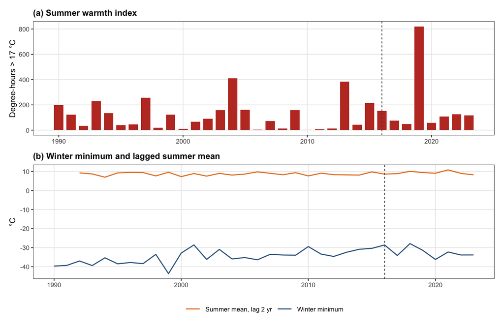

Figure 2: Annual climate variables over the study window from Daymet version 4 daily forcings, 1990 to 2023. (a) Summer warmth index: cumulative degree-hours above 17 °C, June to September, the seasonal window in which development above the univoltinism threshold accrues. (b) Winter minimum daily temperature, November to March, when overwintering stages beneath the bark are exposed to cold mortality; the two-year lagged summer mean tracks the delayed population response. The dashed line marks the 2016 outbreak onset.

```r
library(ggplot2); library(patchwork)
th <- theme_bw(base_size = 8) +
  theme(panel.grid.minor = element_blank(),
        plot.title = element_text(face = "bold", size = 8.5))
pa <- ggplot(clim, aes(year, warmth)) +
  geom_col(fill = "#C0392B", width = .75) +
  geom_vline(xintercept = 2016, linetype = "22", colour = "grey30") +
  labs(title = "(a) Summer warmth index", y = "Degree-hours > 17 °C",
       x = NULL) + th
pb <- ggplot(clim, aes(year)) +
  geom_line(aes(y = winter_min, colour = "Winter minimum"), linewidth = .5) +
  geom_line(aes(y = summer_mean_lag2, colour = "Summer mean, lag 2 yr"),
            linewidth = .5) +
  geom_vline(xintercept = 2016, linetype = "22", colour = "grey30") +
  scale_colour_manual(NULL, values = c("Winter minimum" = "steelblue4",
                                       "Summer mean, lag 2 yr" = "#E67E22")) +
  labs(title = "(b) Winter minimum and lagged summer mean",
       y = "°C", x = NULL) + th + theme(legend.position = "bottom")
pa / pb
```

These enter the subsequences as additional per-year channels; Daymet currently extends through 2023, and later years carry an availability flag in place of measured values until the forcing series updates. One property is stated plainly: within a single study window, climate varies far more between years than between cells, so these channels contribute chiefly timing information; whether that information improves detection is exactly what the third hypothesis tests, and elevational lapse across the window’s 1,500 m relief provides the residual spatial contrast.

## Architectures

Two deep learning networks are applied to the time series, following the comparative design of Perbet et al. (2024). TempCNN applies one-dimensional convolutions along the temporal axis of a satellite time series, learning discriminative temporal features without handcrafted metrics; convolutional layers are applied to the temporal sequence without pooling, which degrades performance in this setting (Pelletier et al., 2019), followed by fully connected layers and task heads. The Transformer encoder classifies sequences through self-attention, weighting every observation of the series against every other and thereby capturing long-range temporal dependencies without recurrence (Rußwurm & Körner, 2020); for sequence-to-label tasks only the encoder stack is required, multi-head attention blocks followed by feed-forward layers. In boreal disturbance classification TempCNN matched or exceeded a LandTrendr-plus-random-forest workflow, with its largest margins on partial disturbance classes, and the Transformer performed within two accuracy points of it (Perbet et al., 2024); both architectures are retained because their attention patterns differ instructively on gradual disturbances.

## Baseline model

The null model reproduces the stand-scale change analysis that defines the current detection floor (Zwieback et al., 2024). Pre-outbreak and post-outbreak summer mean reflectances are differenced per stand cell, and the SWIR difference, with the normalized burn ratio family it anchors (Cohen et al., 2017; Kennedy et al., 2010), predicts mortality presence and severity through a calibrated univariate model fitted on training folds only. SWIR change is the strongest single-band signal for beetle-killed spruce at Landsat scale but relates clearly to severity only above 0.1 (Zwieback et al., 2024), and index-based methods generally weaken on partial and gradual disturbance (Cohen et al., 2017; Senf et al., 2017).

## Model training

TempCNN and the Transformer encoder are trained on identical inputs with two heads: a severity output, classified at the pre-registered breaks with the continuous fraction retained for regression reporting, and a relative onset-year output. Both networks are implemented through the sits package (Simoes et al., 2021) on its torch backend, which also supplies the tuning, validation and uncertainty tools applied below. Architectures follow Pelletier et al. (2019) and Perbet et al. (2024); optimisation uses Adam with cross-entropy losses, dropout and weight decay, with hyperparameters tuned on a validation split held apart from all test blocks. The SWIR change baseline is fitted on the same training cells. Ablation variants for the second and third hypotheses retrain the identical architecture with, respectively, point onset labels in place of intervals, and climate channels removed. Exact architecture depths, loss weights and schedules are fixed at pre-registration; training runs on cloud graphics hardware with configurations and logs archived alongside the analysis code.

## Endmember calibration

The synthetic test below stands or falls on one quantity: how much a stand’s reflectance moves per unit of dead-crown area. Assuming that quantity would make the test circular, because a small assumed contrast guarantees that low severities are unrecoverable. It is therefore measured, from the published crown delineations rather than from any severity product. Within each delineation area the crowns are rasterised to the 90 m stand grid as the fraction of each cell they cover, giving an observed areal severity that depends on no model. Composite reflectance for the same cells is then regressed on that fraction, band by band, at the 2021 growing season the crowns were delineated in. Under linear areal mixing the intercept estimates the live stand spectrum and the slope estimates the difference between a fully dead and a fully live stand, which is exactly the endmember the simulation needs.

Two limits are stated rather than buried. The delineation areas fall inside the reference footprint held out as fold 8, so this uses fold-8 imagery to fix a simulation parameter; it is treated as a pilot calculation, declared as such, and no fold-8 cell enters model training. And the areas were selected for crown density, so they sample the severity range unrepresentatively, which biases the range covered but not the per-unit contrast being estimated.

```r
em_csv <- file.path(dirname(inputs), "03.outputs", "endmember.csv")
if (!file.exists(em_csv)) {
  library(sf)
  BANDS4 <- c("red", "nir", "swir16", "swir22")
  post <- rast(file.path(comp_dir, "s2_2021.tif"))[[BANDS4]]
  # The simulation offsets each cell from its OWN live spectrum, so the quantity
  # to estimate is the change per unit severity, not the between-cell contrast
  # at one date. Regressing levels estimates a different and far noisier thing:
  # it asks whether cells that hold more dead crowns look different from cells
  # that do not, which stand type, slope and shadow dominate. Differencing
  # against a pre-outbreak baseline removes every stable per-cell difference.
  # The baseline is Landsat and the post state Sentinel-2, so a cross-sensor
  # offset enters; it is common to all cells and lands in the intercept, leaving
  # the slope on severity identifiable.
  pre <- mean(rast(file.path(comp_dir, "ls_2014.tif"))[[BANDS4]],
              rast(file.path(comp_dir, "ls_2015.tif"))[[BANDS4]])
  grid <- c(post, post - pre)     # levels first, then the post minus pre change
  names(grid) <- c(BANDS4, paste0("d_", BANDS4))
  cells <- list()
  for (f in lab_f) {
    l <- suppressWarnings(st_read(f, quiet = TRUE))
    if (nrow(l) == 0) next
    if (!identical(st_crs(l)$epsg, 32605L)) {
      if (suppressWarnings(st_bbox(l))[["xmin"]] > 1000) l <- st_set_crs(l, 32605)
    }
    g <- crop(grid, ext(vect(l)) + 180, snap = "out")
    if (ncell(g) < 4) next
    # cover = TRUE gives the fraction of each 90 m cell inside a crown polygon,
    # which is areal severity measured directly, with no model in between.
    fr <- rasterize(vect(l), g[[1]], cover = TRUE, background = 0)
    d <- data.frame(sev = values(fr)[, 1], values(g))
    cells[[basename(f)]] <- d[is.finite(d$sev) & complete.cases(d), ]
  }
  cd <- do.call(rbind, cells)
  cd <- cd[cd$red > 0 & cd$nir > 0, ]
  fit1 <- function(y, b, est) {
    m <- lm(y ~ cd$sev)
    ci <- confint(m)[2, ]
    data.frame(estimator = est, band = b,
               intercept = round(coef(m)[[1]], 4),
               endmember = round(coef(m)[[2]], 4),
               ci_low = round(ci[[1]], 4), ci_high = round(ci[[2]], 4),
               r2 = round(summary(m)$r.squared, 4))
  }
  em <- rbind(
    do.call(rbind, lapply(BANDS4, function(b) fit1(cd[[b]], b, "level"))),
    do.call(rbind, lapply(BANDS4, function(b)
      fit1(cd[[paste0("d_", b)]], b, "change"))))
  em$n_cells <- nrow(cd)
  em$max_sev <- round(max(cd$sev), 3)
  write.csv(em, em_csv, row.names = FALSE)
}
endmember_tbl <- read.csv(em_csv)
```

```r
fmt_tbl(endmember_tbl, right = c("intercept", "endmember", "ci_low",
                                 "ci_high", "r2", "n_cells", "max_sev"))
```

Table 6: Dead-crown endmember estimated from the published crown delineations under two estimators. The level estimator regresses 2021 reflectance on dead-crown fraction across cells; the change estimator regresses the 2021 minus pre-outbreak difference on the same fraction. The endmember column is the fitted change per unit of dead-crown area, so a stand at severity 0.05 moves by one twentieth of the tabulated value. Confidence intervals are 95 percent.

| estimator | band | intercept | endmember | ci_low | ci_high | r2 | n_cells | max_sev |
| --- | --- | --- | --- | --- | --- | --- | --- | --- |
| level | red | 0.0269 | -0.0651 | -0.0901 | -0.0401 | 0.0075 | 3,460 | 0.386 |
| level | nir | 0.3093 | -0.0717 | -0.2045 | 0.0611 | 0.0003 | 3,460 | 0.386 |
| level | swir16 | 0.1530 | -0.0479 | -0.0986 | 0.0028 | 0.0010 | 3,460 | 0.386 |
| level | swir22 | 0.0720 | -0.0176 | -0.0431 | 0.0080 | 0.0005 | 3,460 | 0.386 |
| change | red | -0.0018 | 0.0158 | 0.0010 | 0.0306 | 0.0013 | 3,460 | 0.386 |
| change | nir | 0.0414 | 0.2047 | 0.1295 | 0.2798 | 0.0082 | 3,460 | 0.386 |
| change | swir16 | 0.0225 | 0.1378 | 0.1044 | 0.1712 | 0.0186 | 3,460 | 0.386 |
| change | swir22 | 0.0131 | 0.0819 | 0.0619 | 0.1019 | 0.0183 | 3,460 | 0.386 |

```r
emv <- function(est, b, col = "endmember")
  endmember_tbl[[col]][endmember_tbl$estimator == est & endmember_tbl$band == b]
```

The estimate covers 3460 stand cells reaching a maximum observed dead-crown fraction of 0.386. The two estimators answer different questions and only the second answers the one that matters. Regressing levels asks whether cells holding more dead crowns look different from cells holding none, a comparison that stand composition, slope and canopy shadow dominate; it returns an R² of 0.001 in the shortwave infrared and a slope of the wrong sign, which is a statement about between-cell confounding rather than about mortality. Differencing each cell against its own pre-outbreak state removes those stable differences and estimates the quantity the mixing model actually defines. The change estimator puts the shortwave-infrared endmember at +0.138 with a 95 percent interval of +0.104 to +0.171, against the +0.055 assumed before measurement. The synthetic test below is run at both values so the consequence of the assumption is visible rather than asserted.

Three properties of this estimate constrain how far it can be pushed. The measured shortwave-infrared contrast is roughly two and a half times the assumed one, so the assumption was conservative and the detectability question is correspondingly more open than the first synthetic run implied. Severity nonetheless explains very little of the variance, with R² between 0.001 and 0.019, so these are weak slopes estimated over many cells rather than a tight relationship; all four intervals nonetheless exclude zero. And the near-infrared slope is positive, at +0.205, where dead foliage at crown scale lowers near-infrared reflectance (Zwieback et al., 2024). Two readings are available and this design cannot separate them: canopy loss over a five-year window admits understory response that raises stand near-infrared even as individual crowns darken, or the Landsat baseline and Sentinel-2 post state differ in near-infrared band pass in a way that a common intercept does not absorb. The synthetic test uses the measured vector as estimated, sign included, because substituting the expected sign would reintroduce exactly the assumption this section exists to remove.

## Pipeline validation

Before any labelled data reach the models, the pipeline is tested against a signal whose truth is known because this manuscript injects it. Real trajectories are drawn from the analysis cube, so phenology, atmosphere and sensor noise are those of the study area; only the disturbance is synthetic. Mortality is added as linear areal mixing, the observed spectrum becoming the severity-weighted mix of that cell’s own live spectrum and a dead-crown endmember, applied from a known onset year and ramped over two years after Hicke et al. (2024), whose Alaskan *Dendroctonus* fade runs from green through red to gray rather than completing within a season. Two single-band-head models stand in for the pre-registered two-head design until the interval-censored head exists: one classifies the severity stratum, the other the onset year.

```r
out_dir <- file.path(dirname(inputs), "03.outputs")
dir.create(out_dir, showWarnings = FALSE)
syn_f <- file.path(out_dir, c("synthetic_severity_recall.csv",
                              "synthetic_onset_summary.csv"))
if (!all(file.exists(syn_f))) {
  set.seed(20260812)
  YEARS <- 2014:2025
  BANDS <- c(B04 = "red", B08 = "nir", B11 = "swir16", B12 = "swir22")
  N_SAMP <- 4000; N_CAND <- 40000
  STRATA <- c(0, 0.01, 0.03, 0.05, 0.10, 0.20, 1)   # pre-registered breaks
  ONSETS <- 2017:2023
  # Reflectance offset of a pure dead stand from the live stand spectrum. The
  # first is the value assumed before anything was measured; the second is the
  # regression slope from the crown delineations. Running both is the point:
  # the assumed value alone would make the low-severity result circular.
  emc <- endmember_tbl[endmember_tbl$estimator == "change", ]
  em_m <- setNames(emc$endmember, emc$band)
  ENDMEMBERS <- list(
    assumed = c(red = 0.040, nir = -0.060, swir16 = 0.055, swir22 = 0.045),
    measured = em_m[c("red", "nir", "swir16", "swir22")])

  cf <- function(b, y) file.path(cube_dir,
         sprintf("SENTINEL-2_MSI_TBL01_%s_%d-08-01.tif", b, y))
  cand <- sample(ncell(rast(cf("B04", 2014))), N_CAND)
  arr <- array(NA_real_, c(N_CAND, length(YEARS), length(BANDS)))
  for (bi in seq_along(BANDS)) for (yi in seq_along(YEARS)) {
    arr[, yi, bi] <- rast(cf(names(BANDS)[bi], YEARS[yi]))[cand][, 1]
  }
  ok <- apply(arr, 1, function(m) all(is.finite(m)) && all(m > 0 & m < 1))
  ndvi <- (arr[, 1, 2] - arr[, 1, 1]) / (arr[, 1, 2] + arr[, 1, 1])
  sel <- sample(which(ok & !is.na(ndvi) & ndvi > 0.4), N_SAMP)
  base <- arr[sel, , , drop = FALSE]

  n_dist <- N_SAMP / 2
  grp <- rep(seq_len(length(STRATA) - 1), length.out = n_dist)
  sev <- numeric(N_SAMP); onset <- rep(NA_integer_, N_SAMP)
  for (i in seq_len(n_dist)) {
    lo <- max(STRATA[grp[i]], 1e-3); hi <- STRATA[grp[i] + 1]
    sev[i] <- exp(runif(1, log(lo), log(hi)))
    onset[i] <- sample(ONSETS, 1)
  }
  inject <- function(em) {
    o <- base
    for (i in seq_len(n_dist)) {
      yi <- match(onset[i], YEARS)
      for (k in seq(yi, length(YEARS))) {
        w <- min(1, (k - yi + 1) / 2)        # two-year fade to full contrast
        for (bi in seq_along(BANDS))
          o[i, k, bi] <- base[i, k, bi] + w * sev[i] * em[[bi]]
      }
    }
    pmin(pmax(o, 0), 1)
  }
  sev_class <- as.character(cut(sev, STRATA, include.lowest = TRUE))
  sev_class[sev == 0] <- "none"
  onset_class <- ifelse(is.na(onset), "none", as.character(onset))

  to_sits <- function(x, label) {
    ts <- lapply(seq_len(dim(x)[1]), function(i) {
      d <- data.frame(Index = as.Date(sprintf("%d-08-01", YEARS)))
      for (bi in seq_along(BANDS)) d[[names(BANDS)[bi]]] <- x[i, , bi]
      tibble::as_tibble(d)
    })
    tb <- tibble::tibble(longitude = 0, latitude = 0,
      start_date = as.Date("2014-08-01"), end_date = as.Date("2025-08-01"),
      label = label, cube = "SYNTHETIC", time_series = ts)
    class(tb) <- c("sits", class(tb)); tb
  }
  tr_i <- sample(N_SAMP, floor(0.75 * N_SAMP))
  te_i <- setdiff(seq_len(N_SAMP), tr_i)
  run <- function(obs, labels) {
    m <- sits_train(to_sits(obs[tr_i, , , drop = FALSE], labels[tr_i]),
                    sits_tempcnn(epochs = 60, batch_size = 64,
                                 validation_split = 0.2, verbose = FALSE))
    p <- sits_classify(to_sits(obs[te_i, , , drop = FALSE], labels[te_i]),
                       m, progress = FALSE, multicores = 2)
    data.frame(truth = labels[te_i],
               pred = vapply(p$predicted, function(x) x$class[[1]], character(1)))
  }

  recall_rows <- list(); onset_rows <- list()
  for (tag in names(ENDMEMBERS)) {
    obs <- inject(ENDMEMBERS[[tag]])
    rs <- run(obs, sev_class); ro <- run(obs, onset_class)
    bs <- do.call(rbind, lapply(sort(unique(rs$truth)), function(s) {
      i <- rs$truth == s
      data.frame(endmember = tag, stratum = s, n = sum(i),
                 recall = round(mean(rs$pred[i] == s), 3))
    }))
    bs$overall_accuracy <- round(mean(rs$pred == rs$truth), 3)
    recall_rows[[tag]] <- bs
    d <- ro$truth != "none" & ro$pred != "none"
    err <- abs(as.integer(ro$truth[d]) - as.integer(ro$pred[d]))
    onset_rows[[tag]] <- data.frame(endmember = tag,
      n_disturbed_test = sum(ro$truth != "none"),
      classified_disturbed = sum(d),
      onset_mae_years = ifelse(sum(d) > 0, round(mean(err), 3), NA),
      within_1yr = ifelse(sum(d) > 0, round(mean(err <= 1), 3), NA))
  }
  write.csv(do.call(rbind, recall_rows), syn_f[1], row.names = FALSE)
  write.csv(do.call(rbind, onset_rows), syn_f[2], row.names = FALSE)
}
syn_recall <- read.csv(syn_f[1]); syn_onset <- read.csv(syn_f[2])
```

```r
fmt_tbl(syn_recall, right = c("n", "recall", "overall_accuracy"))
```

Table 7: Recovery of an injected signal by severity stratum, on held-out synthetic samples, under two dead-crown endmembers: the value assumed before measurement and the value regressed from the crown delineations. Recall states whether the pipeline recovers a decline of that size, not whether spruce beetle mortality of that severity is detectable.

| endmember | stratum | n | recall | overall_accuracy |
| --- | --- | --- | --- | --- |
| assumed | (0.01,0.03] | 85 | 0.000 | 0.547 |
| assumed | (0.03,0.05] | 80 | 0.000 | 0.547 |
| assumed | (0.05,0.1] | 87 | 0.000 | 0.547 |
| assumed | (0.1,0.2] | 86 | 0.012 | 0.547 |
| assumed | (0.2,1] | 73 | 0.630 | 0.547 |
| assumed | [0,0.01] | 74 | 0.000 | 0.547 |
| assumed | none | 515 | 0.971 | 0.547 |
| measured | (0.01,0.03] | 85 | 0.000 | 0.558 |
| measured | (0.03,0.05] | 80 | 0.000 | 0.558 |
| measured | (0.05,0.1] | 87 | 0.011 | 0.558 |
| measured | (0.1,0.2] | 86 | 0.163 | 0.558 |
| measured | (0.2,1] | 73 | 0.726 | 0.558 |
| measured | [0,0.01] | 74 | 0.000 | 0.558 |
| measured | none | 515 | 0.951 | 0.558 |

```r
sy <- function(tag) syn_recall[syn_recall$endmember == tag, ]
lo_str <- c("[0,0.01]", "(0.01,0.03]", "(0.03,0.05]", "(0.05,0.1]")
best <- function(tag) { d <- sy(tag); d$stratum[which.max(d$recall)] }
peak <- function(tag) max(sy(tag)$recall)
lowmax <- function(tag) { d <- sy(tag); max(d$recall[d$stratum %in% lo_str]) }
on <- function(tag) syn_onset[syn_onset$endmember == tag, ]
```

Under the endmember assumed before measurement, recovery is confined to the largest stratum: recall peaks at 0.97 in the none stratum and reaches at most 0.00 anywhere below 0.10, while undisturbed cells are returned correctly 97% of the time. Under the measured endmember, recall peaks at 0.95 in the none stratum and reaches 0.01 at best below 0.10. Overall accuracy in both cases is carried almost entirely by the undisturbed majority and should not be read on its own. Onset dating is not a skill estimate under either condition: 33 and 103 of 485 disturbed test samples were classified as disturbed at all, so the associated mean absolute errors describe whichever cases carried the strongest severity signal rather than the population.

What this establishes is narrow and worth stating plainly. The cube, the sample assembly, the sits training path and the classification path run end to end and recover a large injected decline together with its date. The comparison between the two endmembers is the informative part: it separates what follows from an arbitrary choice from what follows from the contrast the delineated crowns actually exhibit. Measuring the contrast rather than assuming it roughly trebles the number of disturbed stands the onset model recognises at all and lifts recall in the 0.1 to 0.2 stratum by more than an order of magnitude, yet leaves the strata below 0.1, which are the strata this study exists to address, essentially unrecovered.

That result should not be read as a forecast of H1, for a reason of construction rather than caution. The test scores a seven-way assignment of severity class, whereas H1 is scored as detection at a fixed operating point of 0.90 precision within a single stratum, a materially easier task that a multiclass error rate does not estimate. The simulation also carries no climate channels, so it cannot speak to H3, and it supervises onset as a bare class rather than through the interval-censored likelihood H2 is defined by. It further assumes one endmember for every stand, where real stands vary, and variation blurs rather than sharpens. What can be said is bounded and still useful before any label exists: on this cube, at the contrast these crowns exhibit, a four-band annual composite carries a weak but non-zero severity signal that a temporal convolutional network converts into skill only above roughly 0.1, and the design’s central claim therefore rests on whether the pre-registered detection framing, the climate channels and the interval supervision together recover what multiclass assignment on spectra alone does not.

## Model evaluation

Evaluation uses block spatial cross-validation, with the study area tessellated into large contiguous blocks assigned wholly to folds to limit spatial autocorrelation leakage (Perbet et al., 2024). Skill is reported per severity stratum. Detection is summarised by full confusion matrices with user’s and producer’s accuracy per class, and by recall at a fixed precision of 0.90, the pre-registered primary metric in the 0.01 to 0.10 stratum. Severity regression is summarised by root-mean-square error, relative RMSE normalised by the stratum mean of the reference severity, mean absolute error, and Theil’s U inequality coefficient with its bias, variance and covariance decomposition, matching and extending the error reporting of Zwieback et al. (2024); the decomposition separates systematic under- or over-prediction from unexplained scatter. Onset dating is summarised by mean absolute error in years. All metrics are reported with fold-wise dispersion. Hypothesis tests are paired and fold-wise: a one-sided Wilcoxon signed-rank on the primary metric difference with a block-bootstrap confidence interval, supported by McNemar’s test on paired cell-level detections. The detectability floor of each method is the lowest severity stratum in which detection skill exceeds the pre-registered threshold, and H1 is tested by paired comparison of deep and baseline skill across folds within the 0.01 to 0.10 stratum. H2 is tested by an ablation: the same architectures retrained with single-epoch labels in place of triangulated onset intervals, compared fold-wise on onset mean absolute error. H3 is tested by the equivalent ablation on inputs: climate-augmented against spectral-only models, compared fold-wise on the primary detection metric. The three confirmatory tests form one Holm-corrected family. The severity product of Zwieback et al. (2024) provides a fully independent evaluation in the Talkeetna to Byers Lake footprint: because the published crown labels of that study now participate in training, this evaluation uses only fold models whose training blocks exclude the footprint entirely. The reconstructed annual outbreak progression is evaluated separately by areal correspondence with annual aerial survey extent, following the map-scale comparison of Perbet et al. (2024), and is reported as descriptive rather than confirmatory. Confusion matrices, class balances and validation support are reported in full (after Hicke et al., 2024).

```r
# Activated after pre-registration. Severity strata for skill-by-severity reporting.
strata <- c(0, 0.01, 0.03, 0.05, 0.10, 0.20, 1)
```

```r
# Activated after pre-registration. SWIR change baseline: pre (2014-2016) minus
# post (2019-2021) summer means per stand cell, per Zwieback et al. (2024).
```

# Results

Values in this section populate when the pre-registered analysis executes; every table below is rendered from the analysis code with its final structure, and cells display as pending until model training completes. No value in this section is estimated, assumed or illustrative.

## Severity skill

Table 8 reports severity-estimation skill per severity stratum for the two deep learning models and the SWIR change baseline on identical stand cells: root-mean-square error, relative RMSE normalised by the stratum mean of the reference severity, mean absolute error, and Theil’s U with its bias, variance and covariance proportions.

```r
strata_lab <- c("0-0.01", "0.01-0.03", "0.03-0.05", "0.05-0.10",
                "0.10-0.20", ">0.20")
models <- c("TempCNN", "Transformer", "SWIR baseline")
sev_shell <- expand.grid(Stratum = strata_lab, Model = models,
                         KEEP.OUT.ATTRS = FALSE)
sev_shell[c("RMSE", "rRMSE", "MAE", "U_Theil", "U_bias", "U_var", "U_cov")] <- "pending"
fmt_tbl(sev_shell, right = c("RMSE","rRMSE","MAE","U_Theil","U_bias","U_var","U_cov"))
```

Table 8: Severity estimation error per severity stratum and model, from block spatial cross-validation. Values pending execution of the pre-registered analysis.

| Stratum | Model | RMSE | rRMSE | MAE | U_Theil | U_bias | U_var | U_cov |
| --- | --- | --- | --- | --- | --- | --- | --- | --- |
| 0-0.01 | TempCNN | pending | pending | pending | pending | pending | pending | pending |
| 0.01-0.03 | TempCNN | pending | pending | pending | pending | pending | pending | pending |
| 0.03-0.05 | TempCNN | pending | pending | pending | pending | pending | pending | pending |
| 0.05-0.10 | TempCNN | pending | pending | pending | pending | pending | pending | pending |
| 0.10-0.20 | TempCNN | pending | pending | pending | pending | pending | pending | pending |
| >0.20 | TempCNN | pending | pending | pending | pending | pending | pending | pending |
| 0-0.01 | Transformer | pending | pending | pending | pending | pending | pending | pending |
| 0.01-0.03 | Transformer | pending | pending | pending | pending | pending | pending | pending |
| 0.03-0.05 | Transformer | pending | pending | pending | pending | pending | pending | pending |
| 0.05-0.10 | Transformer | pending | pending | pending | pending | pending | pending | pending |
| 0.10-0.20 | Transformer | pending | pending | pending | pending | pending | pending | pending |
| >0.20 | Transformer | pending | pending | pending | pending | pending | pending | pending |
| 0-0.01 | SWIR baseline | pending | pending | pending | pending | pending | pending | pending |
| 0.01-0.03 | SWIR baseline | pending | pending | pending | pending | pending | pending | pending |
| 0.03-0.05 | SWIR baseline | pending | pending | pending | pending | pending | pending | pending |
| 0.05-0.10 | SWIR baseline | pending | pending | pending | pending | pending | pending | pending |
| 0.10-0.20 | SWIR baseline | pending | pending | pending | pending | pending | pending | pending |
| >0.20 | SWIR baseline | pending | pending | pending | pending | pending | pending | pending |

## Detection skill

Table 9 reports the confusion-matrix summary per stratum: user’s and producer’s accuracy and the primary metric, recall at 0.90 precision, with fold-wise dispersion. Table 10 carries the H1 test: the fold-wise paired difference in the primary metric between each deep model and the baseline within the 0.01 to 0.10 stratum, its block-bootstrap confidence interval, the one-sided Wilcoxon signed-rank statistic, and the McNemar cell-level check. The detectability floor of each model is the lowest stratum whose primary metric exceeds the pre-registered threshold.

```r
det_shell <- expand.grid(Stratum = strata_lab, Model = models,
                         KEEP.OUT.ATTRS = FALSE)
det_shell[c("UA", "PA", "R90", "R90_sd")] <- "pending"
fmt_tbl(det_shell, right = c("UA","PA","R90","R90_sd"))
```

Table 9: Detection skill per severity stratum and model: user’s accuracy (UA), producer’s accuracy (PA), and recall at 0.90 precision (R90, the pre-registered primary metric), with fold-wise standard deviation. Values pending execution of the pre-registered analysis.

| Stratum | Model | UA | PA | R90 | R90_sd |
| --- | --- | --- | --- | --- | --- |
| 0-0.01 | TempCNN | pending | pending | pending | pending |
| 0.01-0.03 | TempCNN | pending | pending | pending | pending |
| 0.03-0.05 | TempCNN | pending | pending | pending | pending |
| 0.05-0.10 | TempCNN | pending | pending | pending | pending |
| 0.10-0.20 | TempCNN | pending | pending | pending | pending |
| >0.20 | TempCNN | pending | pending | pending | pending |
| 0-0.01 | Transformer | pending | pending | pending | pending |
| 0.01-0.03 | Transformer | pending | pending | pending | pending |
| 0.03-0.05 | Transformer | pending | pending | pending | pending |
| 0.05-0.10 | Transformer | pending | pending | pending | pending |
| 0.10-0.20 | Transformer | pending | pending | pending | pending |
| >0.20 | Transformer | pending | pending | pending | pending |
| 0-0.01 | SWIR baseline | pending | pending | pending | pending |
| 0.01-0.03 | SWIR baseline | pending | pending | pending | pending |
| 0.03-0.05 | SWIR baseline | pending | pending | pending | pending |
| 0.05-0.10 | SWIR baseline | pending | pending | pending | pending |
| 0.10-0.20 | SWIR baseline | pending | pending | pending | pending |
| >0.20 | SWIR baseline | pending | pending | pending | pending |

```r
h1_shell <- data.frame(Model = c("TempCNN", "Transformer"),
                       Delta_R90 = ".", CI95 = ".", Wilcoxon_p = ".",
                       McNemar_chisq = ".", Floor = ".")
fmt_tbl(h1_shell, right = c("Delta_R90","CI95","Wilcoxon_p","McNemar_chisq","Floor"))
```

Table 10: Test of H1 in the 0.01 to 0.10 severity stratum: fold-wise paired difference in recall at 0.90 precision against the SWIR baseline, block-bootstrap 95% confidence interval, one-sided Wilcoxon signed-rank p-value, and McNemar chi-squared on paired cell-level detections. Values pending execution of the pre-registered analysis.

| Model | Delta_R90 | CI95 | Wilcoxon_p | McNemar_chisq | Floor |
| --- | --- | --- | --- | --- | --- |
| TempCNN | . | . | . | . | . |
| Transformer | . | . | . | . | . |

## Onset dating

Table 11 reports onset-year error under the two supervision regimes, testing H2: mean absolute error and root-mean-square error in years, the share of predictions falling within the label bracket, and the fold-wise paired difference between triangulated and single-epoch supervision.

```r
onset_shell <- expand.grid(Model = c("TempCNN", "Transformer"),
                           Supervision = c("Triangulated", "Single-epoch"),
                           KEEP.OUT.ATTRS = FALSE)
onset_shell[c("MAE_yr", "RMSE_yr", "In_bracket", "Delta_MAE", "Wilcoxon_p")] <- "pending"
fmt_tbl(onset_shell, right = c("MAE_yr","RMSE_yr","In_bracket","Delta_MAE","Wilcoxon_p"))
```

Table 11: Onset-year estimation error by model and supervision regime (triangulated two-epoch intervals against single-epoch labels), with the H2 paired test. Values pending execution of the pre-registered analysis.

| Model | Supervision | MAE_yr | RMSE_yr | In_bracket | Delta_MAE | Wilcoxon_p |
| --- | --- | --- | --- | --- | --- | --- |
| TempCNN | Triangulated | pending | pending | pending | pending | pending |
| Transformer | Triangulated | pending | pending | pending | pending | pending |
| TempCNN | Single-epoch | pending | pending | pending | pending | pending |
| Transformer | Single-epoch | pending | pending | pending | pending | pending |

## Climate contribution

Table 12 reports the third hypothesis: fold-wise paired differences in the primary detection metric and in onset error between climate-augmented and spectral-only models.

```r
h3_shell <- data.frame(Model = c("TempCNN", "Transformer"),
                       Delta_R90 = "pending", Delta_MAE_yr = "pending",
                       CI95 = "pending", Wilcoxon_p = "pending")
fmt_tbl(h3_shell, right = c("Delta_R90", "Delta_MAE_yr", "CI95", "Wilcoxon_p"))
```

Table 12: Test of H3: climate-augmented against spectral-only models, fold-wise paired differences with Holm-corrected one-sided Wilcoxon tests. Values pending execution of the pre-registered analysis.

| Model | Delta_R90 | Delta_MAE_yr | CI95 | Wilcoxon_p |
| --- | --- | --- | --- | --- |
| TempCNN | pending | pending | pending | pending |
| Transformer | pending | pending | pending | pending |

## Independent evaluation

Table 13 reports agreement with the untouched severity reference of Zwieback et al. (2024) in the Talkeetna to Byers Lake footprint, using only fold models whose training excluded the footprint: the same error slate as Table 8 at 90 m and 30 m support, alongside the published within-study errors of the reference itself for context, which are not directly comparable and are marked as such.

```r
ind_shell <- expand.grid(Support = c("90 m", "30 m"), Stratum = strata_lab,
                         KEEP.OUT.ATTRS = FALSE)
ind_shell[c("RMSE", "rRMSE", "MAE", "U_Theil")] <- "pending"
fmt_tbl(ind_shell, right = c("RMSE","rRMSE","MAE","U_Theil"))
```

Table 13: Agreement with the independent severity reference at 90 m and 30 m support, per severity stratum. Reference-published errors shown for context only; support and reference data differ. Values pending execution of the pre-registered analysis.

| Support | Stratum | RMSE | rRMSE | MAE | U_Theil |
| --- | --- | --- | --- | --- | --- |
| 90 m | 0-0.01 | pending | pending | pending | pending |
| 30 m | 0-0.01 | pending | pending | pending | pending |
| 90 m | 0.01-0.03 | pending | pending | pending | pending |
| 30 m | 0.01-0.03 | pending | pending | pending | pending |
| 90 m | 0.03-0.05 | pending | pending | pending | pending |
| 30 m | 0.03-0.05 | pending | pending | pending | pending |
| 90 m | 0.05-0.10 | pending | pending | pending | pending |
| 30 m | 0.05-0.10 | pending | pending | pending | pending |
| 90 m | 0.10-0.20 | pending | pending | pending | pending |
| 30 m | 0.10-0.20 | pending | pending | pending | pending |
| 90 m | >0.20 | pending | pending | pending | pending |
| 30 m | >0.20 | pending | pending | pending | pending |

## Outbreak progression

Table 14 compares reconstructed annual outbreak area against the aerial survey record, reported as descriptive correspondence: mapped area, surveyed area, their ratio, and the intersection-over-union of the footprints per year.

```r
prog_shell <- data.frame(Year = 2016:2025)
prog_shell[c("Mapped_kha", "Surveyed_kha", "Ratio", "IoU")] <- "pending"
fmt_tbl(prog_shell, right = c("Mapped_kha","Surveyed_kha","Ratio","IoU"))
```

Table 14: Reconstructed annual outbreak area against aerial survey extent, 2016 to 2025, descriptive. Values pending execution of the pre-registered analysis.

| Year | Mapped_kha | Surveyed_kha | Ratio | IoU |
| --- | --- | --- | --- | --- |
| 2,016 | pending | pending | pending | pending |
| 2,017 | pending | pending | pending | pending |
| 2,018 | pending | pending | pending | pending |
| 2,019 | pending | pending | pending | pending |
| 2,020 | pending | pending | pending | pending |
| 2,021 | pending | pending | pending | pending |
| 2,022 | pending | pending | pending | pending |
| 2,023 | pending | pending | pending | pending |
| 2,024 | pending | pending | pending | pending |
| 2,025 | pending | pending | pending | pending |

# Discussion

## Limitations

Five limitations are known by design. First, crown labels derive from visual interpretation of sub-metre imagery, so fully occluded dead spruce under closed deciduous canopy are absent from both training and reference data, and severity is accordingly a minimum estimate in dense mixed stands (Zwieback et al., 2024). Second, the harmonized Sentinel-2 surface reflectance archive over Alaska begins effectively in 2019, so the first three outbreak years rest on the sparser Landsat record, and onset estimates for stands that died early carry wider intervals. Third, the independent severity reference is itself a model product with documented error structure, not ground truth; agreement with it bounds, rather than establishes, map accuracy. Fourth, mortality agent is inferred from context, not confirmed by ground observation, and other agents of spruce death are conflated with beetle kill at unknown but presumed low rates. Fifth, the study area is one outbreak in one region; transfer to the Kenai Peninsula, to Interior Alaska or to other *Dendroctonus* systems is untested and, on the evidence of cross-system transfer failures elsewhere (Kautz et al., 2024), should not be presumed.

# Conclusion

# Data availability

All inputs are publicly retrievable; the download script, checksums and provenance manifest are in the project repository. The severity rasters of Zwieback et al. (2024) are archived at doi:10.5281/zenodo.8423568, the crown labels at doi:10.5281/zenodo.10569990 and the trained network at doi:10.5281/zenodo.10569975; the latter two are distributed under the Creative Commons Attribution 4.0 licence, while the severity rasters carry no declared licence and are used for independent evaluation only, pending clarification with the author. Aerial detection survey data are distributed by the United States Forest Service as public-domain works, and Sentinel-2, Landsat and elevation data are open under their respective public licences. The Maxar mosaics of the State of Alaska Geoportal are accessible for non-commercial use by streaming and are not redistributed here.

## References

Bentz, B. J., Régnière, J., Fettig, C. J., Hansen, E. M., Hayes, J. L., Hicke, J. A., Kelsey, R. G., et al. (2010). Climate change and bark beetles of the western united states and canada: Direct and indirect effects. *BioScience*, *60*(8), 602–613. Oxford University Press (OUP). Retrieved from http://dx.doi.org/10.1525/bio.2010.60.8.6

Berg, E. E., David Henry, J., Fastie, C. L., De Volder, A. D., & Matsuoka, S. M. (2006). Spruce beetle outbreaks on the kenai peninsula, alaska, and kluane national park and reserve, yukon territory: Relationship to summer temperatures and regional differences in disturbance regimes. *Forest Ecology and Management*, *227*(3), 219–232. Elsevier BV. Retrieved from http://dx.doi.org/10.1016/j.foreco.2006.02.038

Cohen, W., Healey, S., Yang, Z., Stehman, S., Brewer, C., Brooks, E., Gorelick, N., et al. (2017). How similar are forest disturbance maps derived from different landsat time series algorithms? *Forests*, *8*(4), 98. MDPI AG. Retrieved from http://dx.doi.org/10.3390/f8040098

Gorelick, N., Hancher, M., Dixon, M., Ilyushchenko, S., Thau, D., & Moore, R. (2017). Google earth engine: Planetary-scale geospatial analysis for everyone. *Remote Sensing of Environment*, *202*, 18–27. Elsevier BV. Retrieved from http://dx.doi.org/10.1016/j.rse.2017.06.031

Hansen, E. M., Bentz, B. J., & Turner, D. L. (2001). Temperature-based model for predicting univoltine brood proportions in spruce beetle (coleoptera: scolytidae). *The Canadian Entomologist*, *133*(6), 827–841. Cambridge University Press (CUP). Retrieved from http://dx.doi.org/10.4039/Ent133827-6

Hicke, J. A., Bright, B. C., Hanavan, R. P., Hudak, A. T., Meddens, A. J. H., Shrestha, A., & Stahl, A. T. (2024). *Remote sensing of forest insect and disease outbreaks in the western united states: Tree, stand, and landscape responses and technologies and methods for detection and attribution*. U.S. Department of Agriculture, Forest Service, Rocky Mountain Research Station. Retrieved from http://dx.doi.org/10.2737/RMRS-GTR-443

Kautz, M., Feurer, J., & Adler, P. (2024). Early detection of bark beetle (ips typographus) infestations by remote sensing – a critical review of recent research. *Forest Ecology and Management*, *556*, 121595. Elsevier BV. Retrieved from http://dx.doi.org/10.1016/j.foreco.2023.121595

Kennedy, R. E., Yang, Z., & Cohen, W. B. (2010). Detecting trends in forest disturbance and recovery using yearly landsat time series: 1. LandTrendr — temporal segmentation algorithms. *Remote Sensing of Environment*, *114*(12), 2897–2910. Elsevier BV. Retrieved from http://dx.doi.org/10.1016/j.rse.2010.07.008

Khatri-Chhetri, P., Wagtendonk, L. van, Hendryx, S. M., & Kane, V. R. (2024). Enhancing individual tree mortality mapping: The impact of models, data modalities, and classification taxonomy. *Remote Sensing of Environment*, *300*, 113914. Elsevier BV. Retrieved from http://dx.doi.org/10.1016/j.rse.2023.113914

Macander, M. J., Nelson, P. R., Nawrocki, T. W., Frost, G. V., Orndahl, K. M., Palm, E. C., Wells, A. F., et al. (2022). Time-series maps reveal widespread change in plant functional type cover across arctic and boreal alaska and yukon. *Environmental Research Letters*, *17*(5), 054042. IOP Publishing. Retrieved from http://dx.doi.org/10.1088/1748-9326/ac6965

Pasquarella, V. J., Brown, C. F., Czerwinski, W., & Rucklidge, W. J. (2023). Comprehensive quality assessment of optical satellite imagery using weakly supervised video learning. *2023 IEEE/CVF conference on computer vision and pattern recognition workshops (CVPRW)* (pp. 2125–2135). IEEE. Retrieved from http://dx.doi.org/10.1109/CVPRW59228.2023.00206

Pastick, N. J., Jorgenson, M. T., Goetz, S. J., Jones, B. M., Wylie, B. K., Minsley, B. J., Genet, H., et al. (2018). Spatiotemporal remote sensing of ecosystem change and causation across alaska. *Global Change Biology*, *25*(3), 1171–1189. Wiley. Retrieved from http://dx.doi.org/10.1111/gcb.14279

Pelletier, C., Webb, G., & Petitjean, F. (2019). Temporal convolutional neural network for the classification of satellite image time series. *Remote Sensing*, *11*(5), 523. MDPI AG. Retrieved from http://dx.doi.org/10.3390/rs11050523

Perbet, P., Guindon, L., Côté, J.-F., & Béland, M. (2024). Evaluating deep learning methods applied to landsat time series subsequences to detect and classify boreal forest disturbances events: The challenge of partial and progressive disturbances. *Remote Sensing of Environment*, *306*, 114107. Elsevier BV. Retrieved from http://dx.doi.org/10.1016/j.rse.2024.114107

Rußwurm, M., & Körner, M. (2020). Self-attention for raw optical satellite time series classification. *ISPRS Journal of Photogrammetry and Remote Sensing*, *169*, 421–435. Elsevier BV. Retrieved from http://dx.doi.org/10.1016/j.isprsjprs.2020.06.006

Senf, C., Seidl, R., & Hostert, P. (2017). Remote sensing of forest insect disturbances: Current state and future directions. *International Journal of Applied Earth Observation and Geoinformation*, *60*, 49–60. Elsevier BV. Retrieved from http://dx.doi.org/10.1016/j.jag.2017.04.004

Sherriff, R. L., Berg, E. E., & Miller, A. E. (2011). Climate variability and spruce beetle (<i>dendroctonus rufipennis</i>) outbreaks in south-central and southwest alaska. *Ecology*, *92*(7), 1459–1470. Wiley. Retrieved from http://dx.doi.org/10.1890/10-1118.1

Simoes, R., Camara, G., Queiroz, G., Souza, F., Andrade, P. R., Santos, L., Carvalho, A., et al. (2021). Satellite image time series analysis for big earth observation data. *Remote Sensing*, *13*(13), 2428. MDPI AG. Retrieved from http://dx.doi.org/10.3390/rs13132428

Thornton, P. E., Shrestha, R., Thornton, M., Kao, S.-C., Wei, Y., & Wilson, B. E. (2021). Gridded daily weather data for north america with comprehensive uncertainty quantification. *Scientific Data*, *8*(1). Springer Science; Business Media LLC. Retrieved from http://dx.doi.org/10.1038/s41597-021-00973-0

Weinstein, B. G., Marconi, S., Bohlman, S., Zare, A., & White, E. (2019). Individual tree-crown detection in RGB imagery using semi-supervised deep learning neural networks. *Remote Sensing*, *11*(11), 1309. MDPI AG. Retrieved from http://dx.doi.org/10.3390/rs11111309

Werner, R. A., Holsten, E. H., Matsuoka, S. M., & Burnside, R. E. (2006). Spruce beetles and forest ecosystems in south-central alaska: A review of 30 years of research. *Forest Ecology and Management*, *227*(3), 195–206. Elsevier BV. Retrieved from http://dx.doi.org/10.1016/j.foreco.2006.02.050

Wu, Q., & Osco, L. P. (2023). Samgeo: A python package for segmenting geospatial data with the segment anything model (SAM). *Journal of Open Source Software*, *8*(89), 5663. The Open Journal. Retrieved from http://dx.doi.org/10.21105/joss.05663

Wulder, M. A., Loveland, T. R., Roy, D. P., Crawford, C. J., Masek, J. G., Woodcock, C. E., Allen, R. G., et al. (2019). Current status of landsat program, science, and applications. *Remote Sensing of Environment*, *225*, 127–147. Elsevier BV. Retrieved from http://dx.doi.org/10.1016/j.rse.2019.02.015

Zabihi, K., Huettmann, F., & Young, B. (2021). Predicting multi-species bark beetle (coleoptera: Curculionidae: Scolytinae) occurrence in alaska: First use of open access big data mining and open source GIS to provide robust inference and a role model for progress in forest conservation. *Biodiversity Informatics*, *16*(1), 1–19. The University of Kansas. Retrieved from http://dx.doi.org/10.17161/bi.v16i1.14758

Zhu, Z., & Woodcock, C. E. (2014). Continuous change detection and classification of land cover using all available landsat data. *Remote Sensing of Environment*, *144*, 152–171. Elsevier BV. Retrieved from http://dx.doi.org/10.1016/j.rse.2014.01.011

Zwieback, S., Young-Robertson, J., Robertson, M., Tian, Y., Chang, Q., Morris, M., White, J., et al. (2024). Low-severity spruce beetle infestation mapped from high-resolution satellite imagery with a convolutional network. *ISPRS Journal of Photogrammetry and Remote Sensing*, *212*, 412–421. Elsevier BV. Retrieved from http://dx.doi.org/10.1016/j.isprsjprs.2024.05.013